# Cutaneous HPV is transcriptionally quiet in skin and carcinoma but productive in warts: a depth-controlled re-mining of public RNA-seq

Authors

Affiliations

Taavi Päll

Institute of Biomedicine and Translational Medicine, University of Tartu

Alla Piirsoo

Institute of Bioengineering, University of Tartu

Marko Piirsoo

Institute of Bioengineering, University of Tartu

Published

October 13, 2026

## Abstract

Most human papillomaviruses (HPVs) are cutaneous beta- and gamma-types residing on skin as commensals, yet their role in cutaneous squamous cell carcinoma (cSCC) remains unsettled, contested between oncogenic “hit-and-run”, protective antiviral immunity, and a virological account in which beta-HPV is transcriptionally restricted by default. Because standard pipelines discard the non-human reads carrying HPV signal, we re-mined public human RNA-seq across skin with a pipeline that screens each library for papillomavirus reads, types positives against the full panel, and scores productive infection from late (L1 major-capsid) transcripts. To control the two confounders, we flagged cell-line and engineered material and scored each library as papillomavirus reads-per-million. HPV signal was concentrated in non-primary material: cell-line and engineered libraries were five-fold enriched for positivity (OR 4.7–5.3, *P* < 10⁻⁸), dominated by integrated HPV16/HPV18, whereas primary skin carried HPV at only 2–4%. Productive infection was abundant in warts and epidermodysplasia verruciformis (64% of libraries). By contrast, cSCC and actinic keratosis, though sequenced four times more deeply, reached the detection floor in only 1.5% of libraries versus 93.2% of controls (Fisher OR 10,183), with median burden six orders of magnitude lower. Depth-adjusted, neoplasia sat marginally above unselected skin (OR 14, *P* = 6.7×10⁻⁶), but only as a trace footprint (any-read OR 2.0, *P* = 5.5×10⁻¹⁰) that deeper sequencing never made productive. A minority of carcinoma and keratosis specimens harbored genuine productive beta-/alpha-HPV infection (HPV12, HPV96, HPV182, HPV16). Cutaneous HPV is productive in warts but quiet in healthy skin and carcinoma: a trace, non-productive footprint that any account of beta-HPV in skin must accommodate. Beyond HPV, this contamination-aware framework, normalized for both sequencing depth and library chemistry, can mine the discarded fraction of public transcriptomes.

**Keywords:** human papillomavirus; beta-papillomavirus; cutaneous squamous cell carcinoma; productive infection; contamination

## Introduction

Human papillomaviruses (HPVs) are a large and ancient family of small, non-enveloped double-stranded DNA viruses that establish infection in stratified squamous epithelia. More than 220 HPV types have now been fully sequenced and formally classified, partitioned by L1 open-reading-frame identity into five genera: *Alpha-*, *Beta-*, *Gamma-*, *Mu-* and *Nupapillomavirus* (Villiers et al. 2004; Bzhalava, Eklund, and Dillner 2015). This genus structure tracks tissue tropism and disease association: the alpha genus contains the mucosal, sexually transmitted types responsible for cervical and other anogenital and oropharyngeal cancers (HPV16, HPV18), whereas the great majority of described types are cutaneous beta- and gamma-HPVs whose natural habitat is the skin (Villiers et al. 2004; Van Doorslaer et al. 2017). Despite outnumbering the medically prominent alpha types, these cutaneous viruses remain comparatively poorly characterized, and the curated reference genomes that make systematic study possible are consolidated in the Papillomavirus Episteme (PaVE; Van Doorslaer et al. (2017)).

Cutaneous beta- and gamma-HPVs behave less like classical pathogens than like members of the commensal skin flora. They are acquired in early life, are ubiquitous on the skin of healthy immunocompetent adults, and persist for months to years as asymptomatic, often low-level infections (Antonsson et al. 2000). Culture-independent surveys of normal-appearing skin reveal striking inter-individual diversity, with multiple co-resident beta- and gamma-genotypes and a continuing discovery of novel types from healthy skin (Foulongne et al. 2012; Nunes, Talpe-Nunes, and Sichero 2018). At DNA level this reservoir is both large and well mapped: shotgun metagenomics of the Human Microbiome Project found HPV in 61.3% of skin samples from healthy subjects, the highest of any body site surveyed (Ma et al. 2014), and type-specific PCR of skin swabs detects beta-HPV in 92% and gamma-HPV in 84% of adults undergoing skin-cancer screening (Rollison, Schell, et al. 2019). Deep sequencing of skin has extended the catalog to 396 HPV types, 229 of them previously unknown (Bzhalava et al. 2014), so the reservoir is also substantially larger than any reference panel describes. What these DNA-based figures cannot say is whether any of that genetic material is being transcribed. In immunocompetent hosts this carriage is overwhelmingly subclinical: most cutaneous HPV infection lies in a “twilight zone” of latency and immune control rather than producing visible lesions (Doorbar 2023). Yet the composition and frequency of this reservoir in healthy skin remain a basic, incompletely answered descriptive question: which types are actually present, and how often?

A minority of cutaneous infections do become overtly productive and lesional, and two settings define this productive extreme. Common, plantar and flat warts are highly productive infections, driven principally by alpha types HPV2, HPV27 and HPV57, the mu type HPV1, and gamma types such as HPV4, in which abundant virion assembly in the differentiating epidermis produces the koilocytes that are the histological signature of active viral replication (Egawa and Doorbar 2017). Epidermodysplasia verruciformis (EV), or Lewandowsky–Lutz dysplasia, is the second: a rare genodermatosis of selective susceptibility to beta-HPVs that manifests as lifelong flat-wart and pityriasis-versicolor-like lesions, with progression to cutaneous squamous cell carcinoma (cSCC) on sun-exposed skin (Orth 2006; Sarah J. de Jong et al. 2018). EV is a Mendelian “experiment of nature”: biallelic loss-of-function in the adjacent keratinocyte genes *EVER1*/*EVER2* (*TMC6*/*TMC8*), and subsequently in *CIB1*, abolishes a keratinocyte-intrinsic restriction of beta-HPV and renders these otherwise-quiescent commensals pathogenic (Ramoz et al. 2002; Lazarczyk et al. 2008; Sarah Jill de Jong et al. 2018). Warts and EV thus provide the natural positive controls for high-burden, transcriptionally active cutaneous HPV infection.

Between asymptomatic carriage and frank lesion lies the most consequential and most contested role of beta-HPV: as a cofactor in the development of cSCC, the second most common human cancer. Beta-HPV is detected at high frequency in actinic keratoses (AK) and cSCC, particularly in organ-transplant recipients and other immunosuppressed patients, whose cSCC risk is elevated many-fold (Howley and Pfister 2015; Rollison, Viarisio, et al. 2019). The mechanistic model that reconciles this association with the virus’s commensal nature is the “hit-and-run” hypothesis: beta-HPV acts early, cooperating with ultraviolet (UV) radiation to expand a field of damaged keratinocytes, but is dispensable for maintenance of the established tumour. Beta-HPV E6 proteins impair the cellular response to UV damage, abrogating ATR signaling and the repair of UV-induced lesions, and disrupt NOTCH and TGF-β signaling to sustain proliferation, without degrading p53 as high-risk alpha-HPV does (Wallace et al. 2012; Meyers et al. 2017). Direct experimental support comes from transgenic and infection models in which genetic deletion of the viral oncogenes after lesions have formed, or transplantation of secondary tumours, leaves carcinoma growth unaffected and viral genomes undetectable (Viarisio et al. 2018; Dorfer et al. 2021), and from UV-dependent MmuPV1 skin carcinogenesis in mice (Uberoi et al. 2016). In human tissue, viral load and transcription are highest in early precursor lesions and decline in established carcinoma, with beta-HPV loads in actinic keratosis exceeding those in the carcinomas that follow (Borgogna et al. 2018; S. J. Weissenborn et al. 2005). That decline is usually read as the model’s signature, but dispensability is a claim about requirement rather than about persistence, and a virus that is no longer needed can still be retained and transcribed. What carries the argument is that papillomavirus episomes are not maintained passively: they are tethered to host mitotic chromosomes by E2, and genomes that lose that tether are cleared as the cell divides (You et al. 2004; Fisher 2015). Once nothing selects for the genome it is therefore diluted out of the expanding clone, which makes the observed decline compatible with hit-and-run rather than diagnostic of it. This view is not unchallenged. T-cell immunity to commensal papillomaviruses has been shown to be actively *protective* against skin carcinogenesis, reframing immunosuppression-associated cSCC as a failure of antiviral immunosurveillance rather than direct viral oncogenesis (Strickley et al. 2019); that claim drew a formal Matters Arising from the opposing camp and a reply (Lambert et al. 2021; Strickley et al. 2021), and the exchange remains unresolved. Two developments since have made the contest less tractable rather than more. First, the protective-immunity account now predicts the same longitudinal pattern as hit-and-run: in UV-damaged skin, papillomavirus colonization blocks the expansion of mutant p53 clones in a CD8<sup>+</sup> T-cell-dependent manner, beta-HPV activity is elevated in sun-exposed human skin carrying such clones, and the expansion of those clones in premalignant lesions is associated with *loss* of beta-HPV (Son et al. 2025). A decline in viral activity along the progression axis is therefore a prediction of both models, not a signature of either. Second, a purely virological explanation for quiescence exists alongside both: the beta-HPV genome represses its own gene expression and replication through the viral E8^E2 protein, and immortalization of human keratinocytes by a beta-HPV genome requires that repressor to be inactivated (Rehm et al. 2022), so transcriptional quiet may be the cis-encoded default state of the virus rather than a statement about immunity or tumour biology. What is missing from this debate is not another mechanism but a measurement: how often, and how actively, cutaneous HPV is actually transcribed across the spectrum from healthy skin to carcinoma.

Resolving these questions requires distinguishing productive infection from latent, abortive, or transformed states, and the viral transcriptional program provides exactly this readout. The papillomavirus life cycle is obligately coupled to keratinocyte differentiation: early genes (*E1*, *E2*, *E5*, *E6*, *E7*) are expressed in basal and proliferating cells, whereas genome amplification and the late capsid genes (*L1*, *L2*) are activated only in the terminally differentiated suprabasal layers, where virions are assembled and shed (Doorbar et al. 2012; Graham 2017). This temporal order is enforced by differentiation-dependent promoter switching, alternative splicing and a shift from early to late polyadenylation (Johansson and Schwartz 2013). Detection of late (L1/L2) capsid transcripts is consequently a hallmark of productive infection, and can be read out directly from RNA sequencing (Klymenko et al. 2017; Borgogna et al. 2014). The contrast is sharpest in cancer: when HPV integrates, the late program, and frequently *E2*, is lost, leaving deregulated *E6*/*E7* as the dominant viral transcripts (Moody and Laimins 2010). Integration itself is not a single state, and reading it from transcription rather than presence is what separates its variants: multi-omic profiling of cervical cancer distinguishes silent from productive integration sites by whether they generate viral-host fusion transcripts, finds only the productive class non-randomly distributed and associated with higher E6/E7 protein and more aggressive disease, and shows the productive fraction rising from carcinoma in situ to advanced disease (Fan et al. 2023). An early-versus-late transcript signature therefore separates the productive warts and EV lesions from the latent carriage of normal skin and from any non-productive footprint in carcinoma.

These questions are, in principle, already answerable from data that exist. Public sequence archives now hold millions of human RNA-seq libraries, and re-mining this resource has repeatedly recovered viral signal that the original studies ignored (Edgar et al. 2022). The obstacle is a near-universal feature of transcriptomic pipelines: reads that do not map to the human genome are discarded at the outset, so any HPV transcripts present are silently filtered away before analysis. Recovering them requires returning to the raw reads and classifying the non-human fraction explicitly, an approach validated by dedicated virus-detection workflows (Yasumizu et al. 2021) and efficient metagenomic classifiers such as Kraken2 (Wood, Lu, and Langmead 2019). Skin is no exception. Screening the off-target reads of commonly available sequencing data across 19 skin tumour types identified HPV42 as the driver of digital papillary adenocarcinoma, present in 96% of cases (Leiendecker et al. 2023), and a multidimensional reprocessing of 8,274 public skin RNA-seq samples from 132 experiments recovered bacterial, protist and viral RNA including HPV among the skin flora it cataloged (Bhargava et al. 2025). Neither discarded-read mining of skin nor its application at archive scale is therefore new; what has not been done is to use it to estimate how often cutaneous HPV is present, which types, and whether the infection is productive. Whether cutaneous HPV is transcriptionally active in skin cancer has in fact been asked directly, by several groups and on several platforms, and the answers converge. Transcriptome sequencing of cSCC concluded that HPV is “not active” in these tumours (Arron et al. 2011); total RNA sequencing of 12 skin lesions, 11 of them HPV DNA-positive, recovered transcripts from one, at a median of 66 million reads (Hultin et al. 2019); whole-transcriptome analysis of 345 post-transplant non-melanoma skin cancers at a median of 35 million reads found HPV transcription in 15 (Arroyo Mühr, Hultin, and Dillner 2021); RNA sequencing of 23 risk-stratified cSCC and normal-skin biopsies found no HPV expression at all, against 64% HPV DNA positivity in the same series (Vandiver et al. 2021); and E6/E7 mRNA in situ hybridization across 243 cutaneous SCC detected high-risk transcripts in 0.9% of the 225 non-anogenital cases (Fujimoto et al. 2019). The convergence is not total: an earlier in situ study found EV-HPV transcripts in 4 of 11 PCR-positive transplant-recipient cSCC, localized to the mid and upper epidermis (Purdie et al. 2005), and whole-transcriptome virome profiling reads cutaneous HPV transcripts readily from EV skin (Saeidian et al. 2023). What no study has yet done is put the question on a denominator large enough, and a control series wide enough, to say what the population-level answer is: the transcriptomic series above run from 11 to 345 specimens, four of the five are confined to lesional tissue with no unselected-skin comparator, the largest is exclusively immunosuppressed and formalin-fixed, and the one covering the widest range of cutaneous types scores transcription of any viral gene rather than productive replication. The question is therefore not whether HPV transcripts can be found in cutaneous neoplasia, which is settled, but at what rate they occur across the skin spectrum, whether they represent productive infection, and how they compare with a lesion in which productive infection is certain. Any such effort must also contend with contamination: the HeLa cell line carries integrated HPV18 and is a pervasive source of spurious HPV18 (and HPV16/HPV38) reads in public datasets, propagated through shared reagents and index hopping (Cantalupo, Katz, and Pipas 2015; Kazemian et al. 2015; Adey et al. 2013). Distinguishing genuine infection from contaminant signal demands coverage-breadth and read-count thresholds, careful flagging of cell-line and engineered samples, and normalization for sequencing depth so that apparent “burden” is not merely a function of how deeply a library was sequenced.

Here we systematically re-mine public human RNA-seq data to characterize the cutaneous HPV transcriptome across tissues and disease states, applying a uniform pipeline that screens every library for papillomavirus reads, types the positives against the full PaVE reference set, and classifies their early-versus-late transcriptional activity. We frame the analysis as a case/control design spanning productive controls (warts and EV), the unselected-skin null, and the open question of HPV-associated skin neoplasia (AK and cSCC), with cell-line and contamination signals identified and depth-normalized throughout. In doing so we address four questions: (1) which HPV types are prevalent in healthy human skin; (2) which HPV types are associated with the spectrum of skin pathology; (3) in which non-traditional tissues HPV transcripts can be detected; and (4) in which transcriptomes the virus reaches the productive (late-transcript) phase of its life cycle. The first and third of these have been answered at DNA level, by body-site metagenomic mapping of healthy carriage (Ma et al. 2014); what is asked here is the transcriptional counterpart, which is a different quantity and, as the results show, a much smaller one.

## Methods

### Overview and implementation

All analyses were performed with a custom, portable workflow implemented in Nextflow DSL2 (≥23.04; Di Tommaso et al. (2017)) and run on an HPC cluster under the SLURM scheduler. Each step runs in an isolated, version-pinned software environment specified per process as both a Conda `environment.yml` and an OCI container image; the exact container build was used for execution, and the versions quoted below are those pinned by the container tags. Default parameter values are given in parentheses and were used unless stated otherwise.

The workflow comprises a one-time reference-construction stage followed by a per-sample pipeline: SRA discovery → FASTQ download → quality control → Kraken2 papillomavirus screen → branch on HPV status (only HPV-positive libraries proceed) → STAR alignment to the HPV reference panel → coverage-based HPV typing → early/late transcript classification → aggregation and reporting.

### HPV reference panel and Kraken2 database

A cutaneous-inclusive HPV reference panel was assembled from the Papillomavirus Episteme (PaVE 2.0; Van Doorslaer et al. (2017)). Because PaVE 2.0 exposes no bulk-FASTA endpoint, genomes were enumerated through its REST API (`GET /api/genome?limit=9999&includeNonRef=true`, which includes non-reference candidate genomes), filtered to human-host entries (`host_common_name == "human"`), and retrieved individually (`GET /api/genome/{locus_id}`), with each genome sequence taken from the returned `itemSequence`. Reference-quality complete HPV genomes from NCBI RefSeq were added on a best-effort basis via Entrez Direct (≥16.2; `"Human papillomavirus"[Organism] AND refseq[filter] AND complete genome[Title]`). Sequences were concatenated and deduplicated by identifier (seqkit ≥2.5; W. Shen et al. (2016)) to yield the final panel (`hpv_all.fasta`; *n* = 455 genomes spanning the alpha, beta, gamma, mu and nu genera plus unclassified candidate types; the panel is built at setup from live PaVE/RefSeq queries and its exact composition depends on build date). A per-type genus lookup was derived from the PaVE ICTV taxonomy array. Gene models for the eight protein-coding ORFs of interest (E1, E2, E4, E5, E6, E7, L1, L2) were extracted from each genome’s PaVE feature annotation, with multi-segment features collapsed to a single span, and written as a GFF3 annotation used downstream for transcript classification.

A STAR genome index was built over the panel (STAR ≥2.7.10; `--genomeSAindexNbases 6` for the small viral genomes). A Kraken2 database (≥2.1.3; Wood, Lu, and Langmead (2019)) was constructed from the NCBI taxonomy and the human reference library (GRCh38), to which all panel HPV genomes were added under a Papillomaviridae taxon, so that human and HPV reads are jointly classified and HPV reads are resolved within the papillomavirus clade.

### Dataset assembly and SRA discovery

Public human RNA-seq libraries were identified by programmatic query of the NCBI Sequence Read Archive through Entrez (Biopython `Bio.Entrez`; pysradb/Biopython container 2.2.1), with every query intersected with a common base filter (`"Homo sapiens"[Organism] AND "RNA-Seq"[Strategy] AND "public"[Access]`). We used three complementary discovery strategies, corresponding to the case/control framing of the study. An unbiased prevalence sweep of human skin and related tissues (the prevalence cohort) estimated baseline HPV-positivity rates in tissue not selected for infection. A targeted productive-lesion query (epidermodysplasia verruciformis, verruca/warts, condyloma) provided positive controls of known productive cutaneous HPV infection. A broadened skin-neoplasia query additionally captured cutaneous squamous cell carcinoma, actinic keratosis and Bowen disease alongside the wider wart/papilloma vocabulary, to interrogate HPV across the AK-to-cSCC setting.

For each retrieved run, metadata were parsed into a per-run samplesheet (one row per SRR). A tissue category was assigned by longest-keyword-first matching of sample title and source fields against a curated keyword table, yielding one of four classes: skin, anogenital, oral, or unclassified (the default, meaning no site keyword was present rather than a site outside the other three). Keywords are matched with letter boundaries on both sides, tolerating a plural suffix, so that a keyword is not matched inside an unrelated word; the boundary is letter-based rather than word-based because SRA free text routinely separates tokens with underscores and digits. Squamous- and basal-cell-carcinoma abbreviations are exempt from the boundary rule, since they legitimately take anatomical affixes (cSCC, RDEB-SCC, SCCIS). A free-text diagnosis was extracted against a fixed pathology vocabulary (carcinoma, SCC, BCC, keratosis, wart, verruca, condyloma, epidermodysplasia verruciformis, dysplasia/CIN, normal/healthy/control, and similar terms), defaulting to “unspecified”. Library layout (single- vs paired-end) was taken from the SRA record. To enable robust downstream parsing, comma-containing free-text fields were retained in a raw samplesheet and stripped from the slim samplesheet consumed by the workflow.

### Read download and quality control

FASTQ files were retrieved from the SRA (Leinonen, Sugawara, and Shumway 2011) with the NCBI SRA Toolkit (3.1.1, pinned; later 3.4.x builds were unstable in our environment) by `prefetch` followed by `fasterq-dump --split-3`, and compressed with pigz. Reads were quality- and adapter-trimmed with fastp (0.23.4; Chen et al. (2018)) using a minimum qualified base quality of Phred 20 (`--qualified_quality_phred 20`) and a minimum retained read length of 36 nt (`--length_required 36`); paired-end libraries additionally used `--detect_adapter_for_pe`. Per-sample failures (withdrawn accessions, network errors) were tolerated by a fail-soft retry-then-ignore policy so that a single unavailable run did not abort a batch. Every library was screened in full: no step subsamples reads, and `fasterq-dump` was run without a spot limit. This matters more than it may appear, because reads deposited from a coordinate-sorted alignment emerge from the SRA in reference order, which places unmapped, and therefore viral, reads at the end of the run; screening only the leading portion of such a library would miss the signal entirely and would do so non-randomly. As a check on the whole path from download to classification, the reads reaching the Kraken2 screen correspond to a median 98.6% of the SRA-reported spot count across the 10,834 screened libraries (5th percentile 85.5%), the small shortfall being fastp quality and length filtering, and the per-group medians span 95.8% to 99.5%, so no sample group was read less completely than another.

### HPV screening and positivity calling

Trimmed reads were classified against the combined human+HPV Kraken2 database (≥2.1.3, paired or single mode as appropriate). HPV-classified reads were enumerated as the count of unique read identifiers assigned to the Papillomaviridae family or any papillomavirus genus/type taxon. A library was called HPV-positive when its HPV read count met or exceeded a threshold of 10 reads (`hpv_min_reads = 10`), and HPV-negative otherwise; HPV-negative libraries were recorded for rate estimation but proceeded no further. HPV-classified reads from positive libraries were extracted (seqtk 1.4), keeping paired mates in register, for targeted alignment. This split, in which every screened library contributes to positivity rates but only positives advance to typing, is the central branch point of the workflow.

### HPV typing

HPV reads from positive libraries were aligned to the HPV reference panel with STAR (2.7.11b; Dobin et al. (2013)) in an end-to-end, splice-disabled configuration appropriate for compact viral genomes (`--alignIntronMax 1`, `--alignEndsType EndToEnd`, `--outFilterMismatchNmax 3`), permitting up to 50 multi-mapping locations (`--outFilterMultimapNmax 50`) to accommodate the high sequence similarity among HPV types. Sorted, indexed BAMs were summarized per reference with `samtools coverage` (samtools 1.21; Danecek et al. (2021)) at a minimum mapping quality of 10. For each reference we recorded read count, covered bases, coverage breadth (fraction of the reference covered ≥1×) and mean depth. A reference was assigned to a sample when it satisfied both coverage breadth ≥ 0.10 (`hpv_min_coverage`) and mean depth ≥ 2 (`hpv_min_depth`); the full per-reference coverage table was retained regardless of assignment. The dual breadth-and-depth criterion guards against spurious assignment from a few reads piling up on a short, conserved region.

### Early/late transcript classification

To distinguish productive from non-productive infection, reads from each HPV-positive alignment were assigned to viral genes with featureCounts (subread ≥2.0; Liao, Smyth, and Shi (2014)) against the PaVE-derived gene annotation (`-t gene -g gene_name`, minimum overlap 20 nt, minimum mapping quality 10; pairing detected directly from the BAM and counted as read pairs when applicable). Per-gene counts were aggregated into an early total (E1, E2, E4, E5, E6, E7) and a late total (L1, L2). An infection was classified as productive when the L1 (major-capsid) read count reached the late-transcript threshold of 3 (`late_transcript_min_reads = 3`). Productivity was gated on L1 specifically, rather than on combined L1+L2 signal, because L1 capsid expression is the more stringent marker of virion-producing late-stage infection, whereas isolated L2 signal can arise from low-level transcription or cross-mapping; this single rule was applied uniformly across all samples and run batches.

### Cell-line, engineered, and contaminant flagging

Because public RNA-seq is heavily populated by cancer cell lines, many carrying integrated HPV (e.g. HeLa/HPV18) that is a well-documented source of spurious HPV signal in archived data (Cantalupo, Katz, and Pipas 2015; Kazemian et al. 2015), every sample was annotated along three independent axes from its metadata using a shared pattern library: is_cell_line (named lines such as HeLa, SiHa, CaSki, HaCaT, A431, plus generic markers like “cell line”, “immortalized”, “passage *n*”, ATCC/DSMZ accessioning, PDX/xenograft), is_engineered (shRNA/siRNA/sgRNA, CRISPR/Cas9, transduction/transfection, lentiviral and plasmid-backbone constructs), and is_in_vitro (cultured but non-immortalized material such as primary keratinocytes/fibroblasts/melanocytes, NHEK, organotypic/raft cultures, organoids, and differentiation time-courses). Explicit “primary” annotations were treated as non-cell-line. These flags annotate rather than exclude samples, so that cell-line positives are retained as positive controls but can be separated from primary-tissue signal at analysis. For the prevalence-sweep cohort, study-level heuristic calls were additionally refined by manual curation through a structured workbook, with precedence sample > study > heuristic, and a provenance label recorded for each overridden call. As a further contaminant guard, low-coverage-breadth assignments (breadth < 0.15) and alpha-genus/HPV16/HPV18 calls were tabulated by study to surface project-level contamination.

### Cohort framing and depth-normalized burden analysis

Because lesional libraries may simply be sequenced more deeply than unselected skin, raw HPV read counts confound infection burden with sequencing depth. To neutralize this, every Kraken2-screened library, including HPV-negative ones, was scored as papillomavirus reads per million (RPM), computed from the Kraken2 report as the Papillomaviridae clade read count divided by the sum of unclassified and root-level clade reads, times 10⁶. Samples were assigned to mutually exclusive sample groups in fixed precedence: `cell_line` (any cell-line flag), `EV` (epidermodysplasia verruciformis diagnosis), `control_productive` (wart/condyloma), `neoplasia` (squamous/carcinoma/SCC/keratosis/Bowen), `contamination_study` (pre-specified contaminated studies), `unselected_skin` (skin tissue), and `other`.

Because these rules read free-text SRA metadata, they mis-file the minority of studies whose submitted metadata is absent or actively misleading. Three such cases were identified by inspecting every library that reached the detection floor, and corrected through a curated override table (`assets/tier_overrides.csv`) in which each row records the accession, the corrected field, and the evidence. (i) A ten-library cohort of epidermodysplasia verruciformis patient skin biopsies (Saeidian et al. 2023) carries only `tissue=Skin` in its per-run metadata, so the diagnosis vocabulary never sees “verruciformis”; these were moved to the `EV` group, which otherwise contained only immortalized EV *culture* models (retained under `cell_line`). (ii) Six libraries from a study of HPV31-positive HaCaT (HaCaT31) cells expose only a knockdown label and `skin` in their parsed fields, so no cell-line pattern can fire; the cell-line flag was set. (iii) One primary cutaneous wart carried a submitter sample label in the SRA `cell_line` attribute and was wrongly flagged as a line; the flag was cleared, returning it to `control_productive`. Together these corrections move 16 of 11,282 screened libraries.

Two further sets of libraries were excluded outright rather than regrouped, because neither a null nor a control describes them. First, 433 16S rRNA amplicon libraries: an amplicon library carries no HPV sequence that could be detected whatever the infection status, so these are structural zeros rather than negative observations, and leaving them in would deflate the background rate every comparison is measured against. Second, fifteen libraries annotated `source_name=Skin or mucosa`, `tissue=adjacent mucosal tissues`, which are the matched adjacent tissue of five condyloma acuminatum donors, each sequenced as an RNA-seq library plus a MeRIP input and IP fraction. Tissue taken millimeters from a productive lesion cannot separate independent infection from spillover out of that lesion, so a detection there is not evidence of virus in the absence of disease, and five donors in three fractions each is one comparison rather than a population. Their lesions are retained in `control_productive`, so neither the productive contrast nor the detection floor calibrated on it is affected. The analyzed cohort is therefore 10,834 libraries. The same `is_cell_line` corrections are applied to the positivity model, so that sample-class definitions are identical across models. Running the pipeline with the override table disabled reproduces the uncorrected group assignment exactly, and both outputs are retained. A control-calibrated detection floor was defined as the 5th-percentile RPM of non-cell-line productive controls (warts/condyloma); libraries below this floor were considered “not detected at control level”. To show that any group difference was not an artifact of depth, the fraction of libraries at or above the detection floor was additionally computed within matched total-read bins (<5M, 5–10M, 10–20M, 20–40M, >40M). The same per-sample table also yielded an HPV-type × sample-group catalog. This analysis pooled the lesion cohorts against the prevalence-sweep null and used the curated cell-line flags. Logistic-regression models (positivity by sample class; productive-level detection by sample group with a log<sub>10</sub> sequencing-depth covariate) and Fisher exact tests were fitted in R; Wilson intervals are reported for proportions. As a robustness check, the positivity, depth-controlled detection and productivity models were additionally refitted as Bayesian logistic regressions with explicit weakly-informative priors, namely Normal(0, 2.5) on the log-odds coefficients and Normal(0, 5) on the intercept, applied directly to the log-odds scale rather than as flat or improper defaults, using rstanarm (Goodrich et al. 2024) (four Markov chains of 2,000 iterations; convergence confirmed by $\hat{R} \le 1.004$ with no divergent transitions). Effects are summarized by the posterior median odds ratio, its 95% credible interval, and the posterior probability of a positive effect; the near-separated productive-controls-versus-skin contrast was additionally checked under a heavier-tailed Student-*t*(3) prior (Table S3).

### Library-selection chemistry

Sequencing depth bounds what a viral-transcript survey can detect, and RNA-selection chemistry bounds it in a second, independent way: poly-A capture recovers polyadenylated early transcripts efficiently but is inefficient for the rest of the viral pool, so two libraries of equal depth need not have equal power to detect HPV. Chemistry was therefore looked up for every library in the burden analysis and entered alongside depth. SRA RunInfo `LibrarySelection` was fetched for the exact accession set already analyzed, with no fresh search, so the cohort is unchanged (`bin/fetch_library_selection.py`). That field is authoritative where it carries a specific value (“PolyA”, “Oligo-dT”, “Inverse rRNA”, “RANDOM”) but is the generic “cDNA” for 74.6% of libraries, so the free-text `LIBRARY_CONSTRUCTION_PROTOCOL` and `DESIGN_DESCRIPTION` records were fetched in a second pass and matched against curated poly-A and rRNA-depletion phrase sets (`bin/classify_library_chemistry.py`). Libraries whose text supports both calls, or neither, are held at `unspecified` rather than assigned, and the amplification chemistries that are neither selection (3’-barcoded droplet libraries, SMART template-switching) are kept as their own levels rather than pooled with poly-A capture. This resolved chemistry for 6,736 of 10,834 libraries (62.2%).

The two-source procedure is necessary rather than merely convenient, and the graded cervical validation series is the demonstration: every one of its libraries is filed in SRA as `LibrarySelection = cDNA`, while its construction protocol reads “Ribosomal RNA was deleted”. Run as a blind test, the classifier recovers rRNA depletion for 15/15 of them from protocol text alone, which is also the independent confirmation that the series is rRNA-depleted rather than poly-A-selected.

### Integration status: E1:E2 transcript ratio and virus–host junctions

Integration of a papillomavirus genome disrupts the E2 open reading frame, which represses E6 and E7. Because E1 and E2 are encoded on the same early transcript, their read counts track one another unless that disruption has occurred, so their ratio reports integration from the transcript classification already computed for every library. Libraries with at least five combined E1 and E2 reads were scored as log<sub>2</sub>((E1 + 0.5)/(E2 + 0.5)); separation between groups was quantified as the area under the ranked ratio and by Wilcoxon rank-sum test. A ratio is undefined where integration has proceeded to the point that the early region is lost apart from E6 and E7, since E1 and E2 are then both silent. Those libraries were called by a second criterion: at least five combined E6 and E7 reads, fewer than five combined E1 and E2 reads, and no more than 5% of viral reads assigned to L1 or L2, which is the integrated-carcinoma pattern of oncogene transcription without a late program. A library was called integration-like if either criterion fired; the two are reported separately because the first is blind to the material the second detects.

The ratio was validated against direct evidence of integration in a subset of 17 libraries spanning its range. Reads were aligned with STAR (Dobin et al. 2013) to a combined index of GRCh38 and the HPV reference panel, with chimeric detection enabled (`--chimSegmentMin 20`, `--chimJunctionOverhangMin 15`), and chimeric junctions were retained when one side fell on an HPV contig and the other on a human chromosome. Integration was scored not by the number of such junctions, which scales with viral depth and is largest in episomal libraries, but by their **clustering**: the fraction of a library’s junctions falling at its single most-supported coordinate pair, since a genuine integration yields one recurrent junction whereas chimeric-read artifacts are scattered. Observed values were bimodal with an empty interval between 0.00–0.03 and 0.33–0.46, and a threshold of 0.2 was placed within it. The limit of a negative call was set empirically rather than by model: integration was called in a library carrying as few as 2,776 HPV reads, which bounds the viral depth at which absence is informative.

The ratio was validated externally on a graded cervical series (BioProject PRJNA612785, study SRP252916): HPV-negative normal cervical epithelium, HPV16-positive normal epithelium, HPV16-positive high-grade squamous intraepithelial lesion and HPV16-positive squamous carcinoma, six cases per arm, all paired-end and rRNA-depleted rather than poly(A)-selected. Libraries were typed with the same pipeline and scored with the same criteria and thresholds as the skin cohort, with the study’s own design arms supplied in place of the group assignment (`bin/e1e2_integration_marker.R --groups`), so the marker was evaluated against labels it had no part in assigning. Single-cell and single-nucleus libraries are excluded from the marker by default throughout, since 3’-biased barcoded coverage cannot support a ratio across the early region; truncating such libraries does not remedy this, so they are dropped rather than downsampled.

### Independent DNA reservoir from public metagenomes

The presence axis against which the transcriptional result is read comes from a published petabase-scale papillomavirus catalog rather than from our own pipeline. Shen et al. screened the Logan assembly of 27 million archived sequencing libraries (Chikhi et al. 2024) for papillomavirus contigs by profile-HMM detection of the conserved L1 B and I domains and clustered them into operational types (J. Y. Q. Shen et al. 2026); we re-tabulated their released cluster-by-library table by body site. Libraries were bucketed by the BioSample organism field into skin (`human skin metagenome`, `skin metagenome`), vaginal and gut metagenomes. The skin taxon also carries environmental transit surfaces and non-human animal skin, which were removed with a curated run exclusion list built from BioSample attributes (`bin/build_skin_run_exclusions.py`). Each contig cluster was mapped to an HPV type through the study’s own taxonomy demarcation table and then to a genus through the same type-to-genus map used for our RNA catalogs, so the two modalities are labeled identically; a cluster with a papillomavirus identity that resolves to no genus is reported as *Unresolved* and one with no reference match as *Novel*.

All quantities from this catalog are compositions conditional on positivity: the denominator is the HPV-positive libraries of a body site, and a library carrying types of two genera contributes to both, so genus proportions within a site do not sum to one. No prevalence is computed from the catalog, since a defensible denominator would require the screened-library count per body site to be reconstructed under the same freeze applied to the numerator. The type-level comparison against our own data joins the reservoir types onto both RNA catalogs, the assigned catalog (Table S1) and the trace catalog (Table S6, at least five best-hit reads, MAPQ ≥ 20, and a majority of the library’s primary alignments on that reference), so that a type below the assignment threshold in skin RNA is reported as a trace detection and never as an absence. This tabulation is implemented in `dna_rna_triangulation/shen_reservoir_by_tissue.R` and `dna_rna_triangulation/skin_dna_vs_rna_corrected.R`, and Figure 5 is built from their outputs by `manuscript/figure_reservoir.R`.

### Execution at scale

For cohorts of thousands of libraries, a chunked driver processed the samplesheet in fixed-size batches (default 100 libraries per chunk). After each successful chunk, per-sample outputs (Kraken2 reports, HPV typing and transcript tables, and HPV status) were aggregated and the chunk’s working directory was deleted to bound disk use; a failed chunk was left intact for inspection and resumed on rerun. A single combined report was generated over the aggregated outputs at completion. Summary tables and figures were produced in R (tidyverse), and the depth-normalized burden analysis was implemented as a standalone R script operating on the aggregated Kraken2 reports, typing tables, and curated sample flags.

## Results

We screened public human RNA-seq libraries for papillomavirus reads under three discovery strategies (Methods): an unbiased prevalence sweep of skin and related tissues (11,556 libraries screened), a targeted query of productive cutaneous lesions providing positive controls (53 wart/epidermodysplasia-verruciformis skin libraries), and a broadened skin-neoplasia sweep capturing cSCC, actinic keratosis (AK) and Bowen disease (1,070 libraries screened). Throughout, every screened library, including HPV-negative ones, was scored as papillomavirus reads per million so that infection burden could be separated from sequencing depth, and each sample was annotated as primary tissue, cell line, or engineered material.

### HPV signal in public RNA-seq is dominated by cell-line and engineered artifacts

In the unbiased sweep, HPV positivity was strongly concentrated in non-primary material. Engineered libraries were HPV-positive in 9.28% of cases (95% CI 5.95–14.19) and cell-line libraries in 10.34% (7.76–13.63), versus only 2.13% (1.87–2.42) of clinical primary-tissue libraries (Table 1). In logistic regression this corresponded to roughly five-fold higher odds of positivity for engineered (OR 4.7, 95% CI 2.8–7.8, *P* = 1.5×10⁻⁹) and cell-line (OR 5.3, 3.8–7.5, *P* = 9.9×10⁻²²) samples relative to clinical tissue (likelihood-ratio *P* = 8.5×10⁻²⁰). These positives were almost entirely the high-risk mucosal alpha types. Of the 34 libraries anywhere in the cohort in which HPV18 met the assignment criterion, 32 were cell lines and the remaining 2 engineered material, so no tissue library carried an assigned HPV18 at all; for HPV16, 24 of 28 were cell lines, leaving 4 in tissue (Table S1). This is the expected signature of integrated-HPV cell lines such as HeLa and of their well-documented cross-contamination of archived sequencing data. Genuine primary skin therefore carries HPV at a low rate (2–4%, below), and the apparent abundance of HPV in public transcriptomes is largely a laboratory artifact that must be partitioned out before any prevalence claim.

The transcripts themselves carry an independent signature of that artifact, in two forms. E1 and E2 are encoded on the same early polycistronic message, so their read counts should track one another; integration characteristically disrupts the E2 open reading frame while sparing E1, inverting the ratio. Cell-line libraries show a median E1:E2 ratio of 129, against 0.27 in productive controls, 0.49 in unselected skin and 0.04 in neoplasia, and the ratio separates cell lines from productive primary infection almost completely (AUC 0.97, Wilcoxon *P* = 2.8×10⁻¹⁴; Figure 1 a). Where integration has gone further and the early region is lost but for E6 and E7, both E1 and E2 fall silent and no ratio can be formed; those libraries instead show oncogene transcription with no late transcription at all, the canonical integrated-carcinoma pattern, and are captured by that criterion. Together the two signatures call 89.2% of 93 cell-line libraries as integration-like (41 by the inverted ratio, 42 by the E6/E7-only pattern the ratio cannot see) while calling 0% of EV biopsies and 4.8% of productive controls, the two groups where infection is episomal by definition. That it reports integration rather than culture is settled by the one cell line in the cohort that maintains its genome episomally, an HPV31-positive HaCaT derivative, which sits at 0.6–1.0 alongside primary tissue rather than with the integrated lines. Applied as a detector, the ratio flags 33 libraries that carry the integration signature without being labeled as cell lines, including melanoma lines under shRNA knockdown recorded with a tissue source of “skin” and cutaneous SCC lines recorded with a carcinoma diagnosis, which is what motivates the engineered group above. The ratio was checked against the event it claims to report. Calling virus–host chimeric reads against a combined human/HPV index in 17 libraries spanning the range of the ratio separates the same groups completely (Figure 1 b), provided integration is scored as a *recurrent* junction rather than a raw count: the fraction of a library’s junctions falling at its single most-supported site is 0.33–0.46 where the ratio indicates integration and 0.00–0.03 where it does not, with no overlap. Raw counts are misleading in the opposite direction, since the two epidermodysplasia-verruciformis libraries generate the largest number of junctions in the panel while being episomal. The positive controls recover the expected answer unprompted: 5 of 5 cell-line libraries are integration-positive, and two independently return the same junction at chromosome 8q24, the documented integration site of the HeLa lineage.

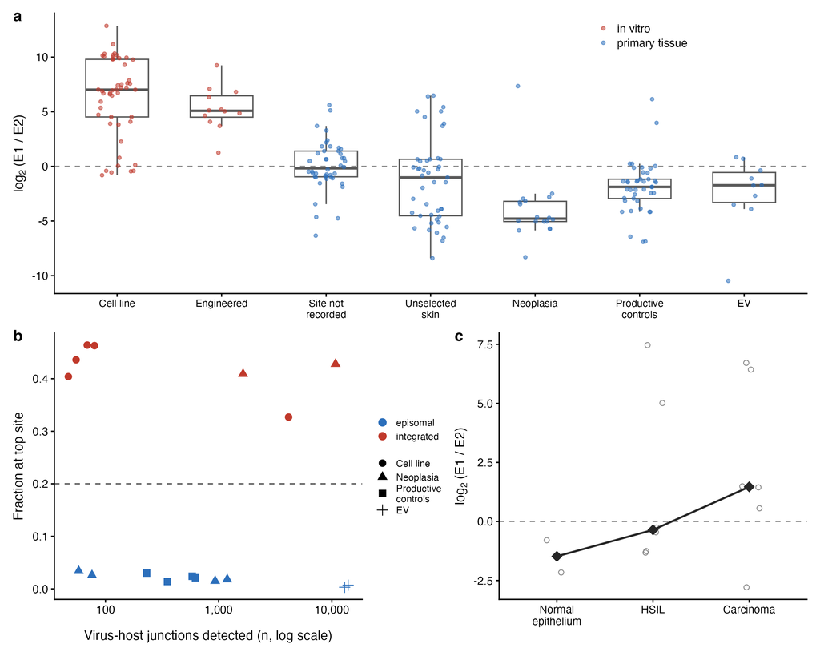

Figure 1: Integration read from transcription, and confirmed against the event itself. (**a**) Distribution of the E1:E2 transcript ratio by sample group, as log<sub>2</sub>((E1 + 0.5)/(E2 + 0.5)) for libraries with at least five combined E1 and E2 reads. E1 and E2 are encoded on the same early message, so their counts track one another unless integration disrupts the E2 open reading frame; the dashed line at zero is parity. In-vitro material (cell lines, engineered cells) sits far above parity, primary tissue at or below it, and the episomal HPV31-positive HaCaT derivative falls with primary tissue rather than with the integrated lines. (**b**) Virus-host chimeric junctions in 17 libraries spanning the range of the ratio, plotted as the fraction of a library’s junctions falling at its single most-supported coordinate pair (*y*) against the raw number of junctions detected (*x*, log scale). The clustering statistic separates the groups completely, with an empty interval between 0.00–0.03 and 0.33–0.46 in which the 0.2 threshold (dashed gray line) is placed. The raw count does not separate them and runs the other way: the two epidermodysplasia verruciformis libraries generate the largest junction counts in the panel (12,979 and 13,937) while being episomal, because chimeric-read callers scatter noise in proportion to viral depth. (**c**) The ratio across a graded cervical series (SRP252916) of HPV16-positive normal epithelium, high-grade squamous intraepithelial lesion (HSIL) and carcinoma, sequenced under one protocol with no cell line in the series; open gray circles are libraries and filled diamonds the arm medians, joined by a solid line; the dashed line at zero is parity, as in (**a**). The normal-epithelium arm contributes two ratio-informative libraries of the three that were HPV-positive, since the third carried two viral reads in total and falls below the five-read criterion. The monotonic rise with grade in primary tissue is what shows the marker reads integration as a biological process rather than culture as a provenance.

Table 1: HPV positivity in public RNA-seq is concentrated in cell-line and engineered libraries, not primary tissue. HPV-positive calls (Kraken2 ≥10 papillomavirus reads) among 11,556 human RNA-seq libraries from the unbiased skin-and-related-tissue sweep, stratified by sample provenance. Positivity percentages are shown with Wilson 95% confidence intervals; odds ratios (95% CI) and *P* values are from a logistic regression with clinical primary tissue as the reference class (overall likelihood-ratio *P* = 8.5×10⁻²⁰). Cell-line and engineered libraries carry roughly five-fold higher odds of HPV positivity than primary tissue, and their positive calls are predominantly the integrated mucosal types HPV16 and HPV18, the expected signature of cell-line contamination.

| Sample class | Libraries (*n*) | HPV+ (*n*) | HPV+ % (95% CI) | Odds ratio (95% CI) | *P* |
| --- | --- | --- | --- | --- | --- |
| Clinical (primary tissue) | 10,946 | 233 | 2.13 (1.87–2.42) | 1 (reference) | n/a |
| Engineered | 194 | 18 | 9.28 (5.95–14.19) | 4.7 (2.8–7.8) | 1.5×10⁻⁹ |
| Cell line | 416 | 43 | 10.34 (7.76–13.63) | 5.3 (3.8–7.5) | 9.9×10⁻²² |

### Skin neoplasia carries only trace HPV, not productive infection, and this is not a depth artifact

The central question, whether HPV is transcriptionally active in cSCC/AK or present only as a residual footprint, was resolved by the depth-normalized burden analysis (Figure 2). Productive controls (warts/condyloma) were detected at or above the control-calibrated detection floor (13.2 RPM) in 93.2% of libraries, with a median burden of 5,408 RPM; the EV biopsy group, sequenced most deeply of all (median 62.6M reads), reached it in 80% (median 229.6 RPM). In stark contrast, the neoplasia group reached this floor in only 1.5% of libraries (median 0.012 RPM), six orders of magnitude below the productive controls, despite being sequenced almost four times more deeply than they were (median 45.2M vs 12.2M reads). Unselected skin, once the EV material that the targeted queries had swept into it was reassigned to its own group (Methods), forms an almost clean null: 0.1% of 7,800 libraries reach the floor.

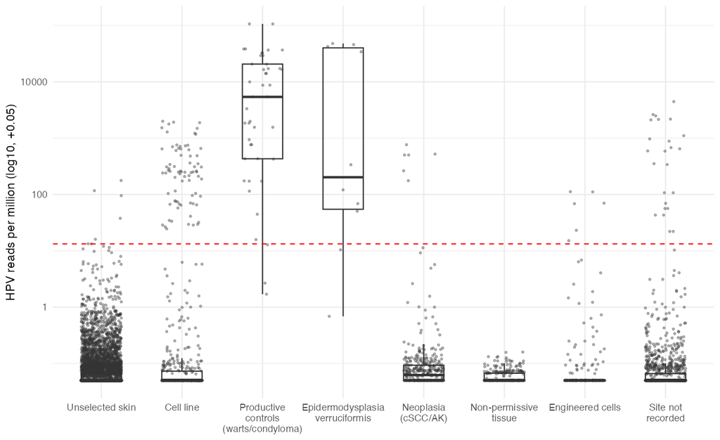

Figure 2: Depth-normalized HPV transcript burden distinguishes productive warts and EV from a trace-level signal in skin neoplasia and unselected skin. Each point is one Kraken2-screened RNA-seq library, scored as papillomavirus reads per million (RPM: Papillomaviridae clade reads ÷ (unclassified + root reads) × 10⁶) and assigned to a sample group: unselected skin (*n* = 7,800), cell lines (697), engineered cells (shRNA/siRNA knockdowns and transgenes, in-vitro material regardless of its disease label; 226), productive controls (warts/condyloma; 44), epidermodysplasia verruciformis biopsies (EV; 10), cutaneous neoplasia (cSCC/actinic keratosis; 406), non-permissive tissue (cutaneous adipose, which has no stratified squamous compartment in which a papillomavirus could replicate; 334), and libraries with no recorded site (1,317; the residual group, 99% of which carries no site keyword in its SRA metadata rather than an identified non-cutaneous site). Points are jittered horizontally; boxes show the median and interquartile range; the *y*-axis is log<sub>10</sub>-scaled (RPM + 0.05). The dashed red line marks the control-calibrated detection floor (13.2 RPM, the 5th percentile of productive-control libraries). Productive controls lie far above the floor (median 5,408 RPM; 93.2% of libraries above floor), as do EV biopsies (80%), whereas neoplasia and unselected skin sit near zero (1.5% and 0.1% above floor) despite neoplasia being sequenced far more deeply than the productive controls (median 45.2M vs 12.2M reads). Group assignment is by metadata precedence with curated corrections (Methods): EV *cultures* (immortalized keratinocyte EV models) remain in the cell-line group, whereas the EV group holds the 10 EV patient skin biopsies.

This gap is not explained by sequencing depth. Modeling productive-level detection (RPM ≥ floor) as a function of sample group and log sequencing depth, productive controls exceeded unselected skin by close to four orders of magnitude (Fisher exact OR 10,183, 95% CI 3,250 to ∞ under separation, *P* = 7.6×10⁻⁹⁹), while neoplasia sat an order of magnitude above skin (OR 14, 95% CI 4.5–46, *P* = 6.7×10⁻⁶). That contrast is easier to read on the absolute scale from which the odds ratios derive: 41/44 productive controls cross the floor, against 6/406 neoplasia libraries and 7/7,800 skin libraries. Neoplasia is thus measurably, but marginally, above a near-zero baseline, and remains roughly 62-fold below the productive controls in detection rate.

Crucially, that marginal excess is not productive burden, and it is not bought by depth. Sequencing depth raised the odds of detecting *any* HPV read (OR per log₁₀ reads 5.2, 4.6–5.9, *P* = 5.1×10⁻¹⁴⁴), but it did not raise the odds of reaching the detection floor, either as a covariate across groups (OR 1.5, 0.4–5.2, *P* = 0.49) or within the neoplasia group alone (OR 1.6, 95% CI 0.1–19, *P* = 0.7). The deepest cSCC/AK libraries, at 327.3M reads, did not cross the productive floor. Consistent with a residual footprint rather than active infection, neoplasia showed a clear excess of *trace* HPV (any read; OR 2.0, 95% CI 1.6–2.4, *P* = 5.5×10⁻¹⁰ vs unselected skin) alongside its small floor-level excess, but neither amounted to productive burden. The depth-matched detection profile confirms the same pattern non-parametrically: across every sequencing-depth bin, productive controls detect at 90–100% while neoplasia and unselected skin stay near zero (Figure S1). At population scale, then, HPV in cutaneous neoplasia is a low-level, transcriptionally inactive trace, a signature consistent with the hit-and-run model, and not the productive infection seen in warts. That trace is also not integrated virus, which the junction analysis measures rather than infers: of 6 HPV-positive cSCC/AK libraries carrying enough viral reads to test, 4 show no integration junction at all, and the 2 that do are HPV16 libraries the broadened query swept in from mucosal disease (Table S4), where integration is the expected state. The negatives are not limited by viral depth: integration was called in a library carrying only 2,776 HPV reads, and every junction-negative cSCC library exceeds that by at least 3.9-fold.

That trace can be taken apart further, because the pipeline writes per-gene read counts for every HPV-positive library. Among the 230 below-floor libraries of unselected skin and neoplasia, 63% carry no reads on any HPV gene at all, a Kraken2 k-mer call that does not survive alignment and gene assignment; 25% carry gene-mapped reads that never reach the productive threshold, 52 of those 57 being early-gene reads with the late program absent; and 13% clear it as low-burden productive infections (Figure S2). The productive controls are the mirror image, 91% productive with a median late-read fraction of 0.367 against 0 across the trace. The sub-threshold signal is therefore neither wholly artifactual nor productive: a dominant technical floor overlying a minority carrying the early-without-late shape of latent or abortive infection, on the cutaneous beta and gamma types of Table S6 rather than the mucosal HPV16/HPV18 that cell-line contamination would deposit.

Nor is it explained by how the libraries were built. Depth is one bound on viral-transcript recovery; RNA-selection chemistry is the other, and poly-A capture is the chemistry least favorable to it. Chemistry was resolved for 6,736 libraries (62.2%) from SRA metadata and library-construction protocol text, and it is not balanced across groups, but the imbalance runs against the negative result rather than producing it: the neoplasia group is rRNA-depleted in 22.9% of libraries against 7.2% of unselected skin (Table S5), while the productive controls, the group in which productive infection is abundant, contain no rRNA-depleted libraries at all. The group in which no productive infection is found was thus built, three times more often than its comparator, with the chemistry most favorable to finding it. Within the two groups of the contrast, and adjusting for depth and group, rRNA-depleted libraries were no more likely than poly-A libraries to carry any HPV read (OR 1.0, 95% CI 0.8–1.2, *P* = 0.93; OR 1.2, 1.0–1.4 across all groups). What did move trace detection, by three- to four-fold at equal depth, was not selection chemistry but amplification: SMART template-switching (OR 4.4) and 3’-barcoded droplet libraries (OR 3.6), a pattern that reads as amplification and barcode-swapping artifact rather than recovery. Adding chemistry to the models leaves both contrasts intact (trace OR 2.0, *P* = 8.7×10⁻¹¹; floor-level OR 14, *P* = 1.7×10⁻⁵). The decisive test is to discard the ambiguity and use only the favorable chemistry: among the 657 rRNA-depleted libraries in the contrast (564 skin, 93 neoplasia from 3 studies, median 45.6M and deepest 96.8M reads), the trace excess in neoplasia is larger still (OR 5.6, 3.4–9.2, *P* = 7.2×10⁻¹²) and not one library, in either group, reached the productive floor.

Pooling actinic keratosis with carcinoma is a choice the data support rather than an assumption. Split on diagnosis, the group comprises 72 AK libraries from 6 studies and 326 cSCC libraries from 19 studies (a further 8 naming both are held out as ambiguous). Both arms sit well above unselected skin, and by almost identical margins: trace HPV at OR 2.6 for AK (*P* = 1.5×10⁻⁴) and OR 1.9 for cSCC (*P* = 5.6×10⁻⁸), and productive-floor detection at OR 14 and 14. Against each other they are indistinguishable on either measure, depth-adjusted: trace OR 1.4 (95% CI 0.8–2.3, *P* = 0.28), and floor-level detection 1/72 against 5/326 (Fisher *P* = 1). The precursor lesion and the carcinoma carry the same trace, non-productive HPV signal, so the group is not averaging two different phenomena.

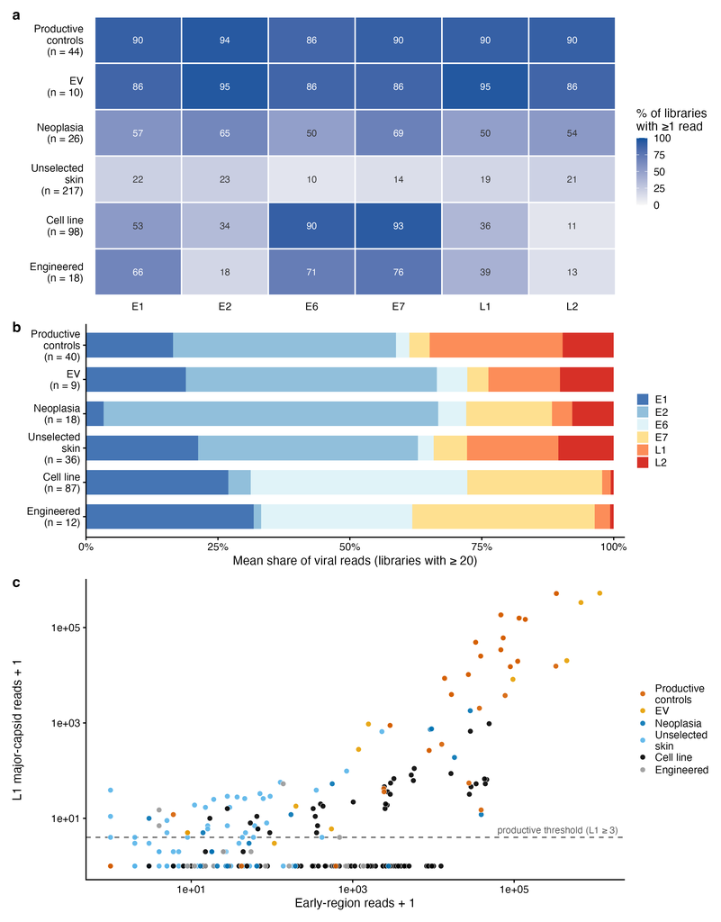

Tissue that cannot host the virus fixes the meaning of that trace. Papillomaviruses replicate only in differentiating stratified squamous epithelium, so cutaneous adipose, blood and neural material offer no permissive compartment at all; the 334 such libraries nonetheless carried a trace HPV read at 28.7%, indistinguishable from the 28% of unselected skin, while 0% reached the detection floor and not one yielded a single assignable HPV type. The background rate of trace HPV reads is therefore not a measure of infection: it is the assay’s floor, reproduced at the same level in tissue where infection is biologically impossible. Read against that control, the trace signal in unselected skin and in neoplasia is what a library returns when no productive infection is present.

Most of the small floor-level excess is in fact attributable to a handful of libraries the broadened SCC/CIN query captured: 3 of the 6 above-floor neoplasia libraries are high-risk *mucosal* HPV16 cases in squamous-cell carcinoma, conservatively retained in the neoplasia group (Table S4). Excluding them halves the effect, lowering cutaneous-neoplasia floor-level detection to 0.7% (OR vs skin 7.5, *P* = 0.0055) and strengthening the productivity contrast against warts/EV (OR 5.2, *P* = 0.0038), so the retained group is the conservative choice.

### The assay detects bona fide productive cutaneous HPV, including genuine infections in primary skin

That the trace neoplasia signal reflects biology rather than assay insensitivity is established by the positive controls, which the pipeline detects robustly. Among targeted wart/EV libraries, 64% (34/53) met the strict productive criterion (≥3 L1 major-capsid reads), spanning the classic cutaneous repertoire: wart-associated alpha types (HPV2, HPV27, HPV57), low-risk mucocutaneous types (HPV6, HPV11), and beta/gamma types (Table S1). Productive infection was significantly more frequent in these controls than among HPV-positive neoplasia libraries (32%, 7/22; Fisher exact OR 3.8, 95% CI 1.2–13, *P* = 0.013).

Even so, a minority of genuine, non-cell-line skin lesions did harbor unambiguous productive infection, showing that the trace-level population result does not exclude real cutaneous HPV disease. The strongest cases were a cSCC skin library productively infected with the beta-type HPV12 (99.8% genome coverage; L1 = 1,803, L2 = 3,546 reads), two HPV16-productive cSCC libraries, and two libraries from cutaneous actinic-keratosis/cSCC cohorts whose SRA records carry no tissue field (an actinic keratosis and a carcinoma) co-infected with the beta types HPV96 and HPV182 at near-complete genome coverage (98–99%) and high depth (60–245×), with hundreds of L1 and L2 reads each (Table S2). These represent the answer to the productive-infection question: bona fide, high-confidence productive beta/gamma-HPV infections do occur in primary skin and skin-associated lesions, but they are the exception against a null background. They do not answer the non-traditional-tissue question, because the residual group that would have to supply that evidence is defined by the *absence* of a site keyword rather than by an identified non-cutaneous site: the two co-infected libraries above sit there only because their cutaneous cohorts record no tissue field at all.

### The HPV type landscape is partitioned by population

Extending this catalog below the assignment threshold answers the descriptive question of *which* types make up the trace. A detection-level re-map of the HPV-positive but untyped libraries, taking the best-hit reference from unique alignments at sub-threshold coverage, resolved a confident low-coverage type for 137 of 325 such libraries across 42 types (Table S6). This recovers the expected commensal signal at the sensitivity floor: healthy skin carried a diverse cutaneous reservoir (40 of 51 resolved skin calls were beta-, gamma- or nu-types, including HPV12/HPV20, HPV4/HPV65/HPV134 and candidate skin-virome types), cutaneous neoplasia the carcinoma-associated beta and gamma types (HPV5, HPV12, HPV182, HPV222), while the mucosal HPV16/HPV18 signal stayed confined to cell-line material and a low-level contamination overlay. These are low-coverage, non-productive detections that identify the type without bearing on productivity, and so extend the type catalog rather than qualify the trace-not-productive conclusion.

A further descriptive feature of the catalog is that types frequently co-occur: 26 of the 148 typed libraries carry two or more assigned references, up to five in one library (Table S7). Because coverage is scored from uniquely-mapped reads alone, cross-mapping between similar types cannot generate these calls. The commonest pairing is HPV11 with HPV42, which co-occur in 8 libraries, against 1 carrying HPV42 alone. We present this as a hypothesis rather than a finding, for the three reasons set out in Table S7. The co-infected libraries are heavily pseudo-replicated, 13 of the 26 coming from 5 donors of one study, each sequenced in three fractions across two SRA submissions; the secondary type in a co-infection is usually near the detection threshold (median depth 9.0×, 39% below 5×), to the point that one donor’s MeRIP input and IP fractions call different second types; and requiring both partners to clear a stricter coverage bar leaves 3 HPV11/HPV42 libraries from 1 of those 5 donors. Whether the pairing reflects genuine dual infection, or only that a second type is called where it happens to be abundant, cannot be settled from this material. The pattern is worth testing in a cohort assembled for the purpose; it cannot be resolved here.

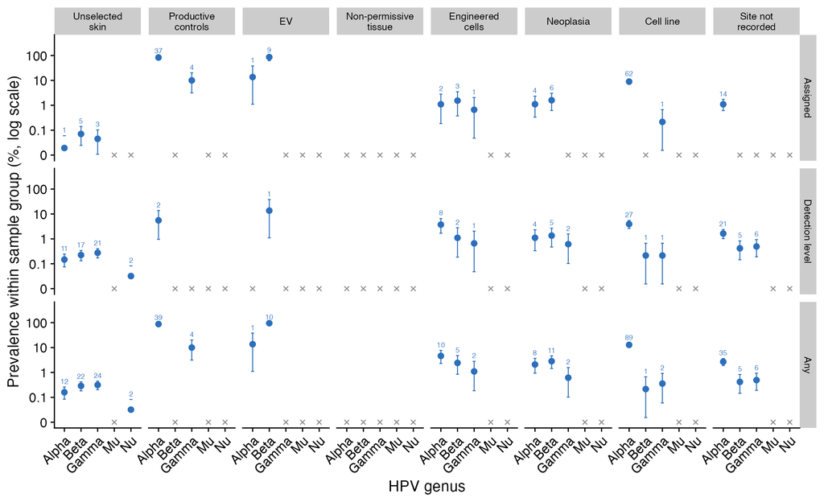

Figure 4: HPV genus prevalence by sample group. The two type catalogs are collapsed from HPV type to HPV genus: the assigned-type catalog of Table S1 (top row), the detection-level trace catalog of Table S6 (middle row), and their union (bottom row), a library contributing to at most one of the first two rows. Each point is the prevalence of that genus within that sample group, meaning the percentage of the group’s libraries in which the genus was detected, estimated as a Beta-Binomial posterior mean under a weakly-informative Beta(0.5, 0.5) prior; the vertical bar through it is the 95% credible interval of that estimate, so it shows how firmly the prevalence is pinned and is wide wherever a group is small. The estimator is the one used in the two tables, so a point here and the corresponding table cell quote the same number. The figure printed above each point is the count of libraries in which the genus was detected; the denominator is the group size (Methods). Gray crosses mark groups in which a genus was never detected; they sit at the axis floor because the *y*-axis is log-scaled and the lowest tick, labeled 0, is a placeholder for zero. A library carrying two types of different genera contributes to both, so the points within a group need not sum to that group’s positivity rate. Read across the bottom row, the figure is the type landscape of the study in one panel: the productive controls are alpha-dominated (39/44 libraries, 88% [77–96]) with a gamma minority (10% [3.1–20]) and no beta at all, the repertoire of cutaneous and mucocutaneous warts; the EV biopsies are the mirror image, essentially pure beta (10/10, 95% [78–100]), the genus the syndrome is defined by; cell lines are alpha (13% [10–15]), the integrated HPV16/HPV18 contamination signature; unselected skin is flat and low, with alpha, beta and gamma at indistinguishable rates near 0.29% [0.18–0.42] and the study’s only nu detections (2/7800 libraries, HPV41), the profile of a sparse commensal reservoir rather than of any one disease; and cutaneous neoplasia is the one tissue group in which beta exceeds alpha (2.8% [1.4–4.6] versus 2.1% [0.94–3.7]), consistent with a beta-HPV footprint, though at prevalences one to two orders of magnitude below the productive groups. The mu genus (HPV1, the classic plantar-wart type) was detected in no group.

### The reservoir the survey is silent against is visible in independent public DNA

A transcriptional survey can only report silence against a reservoir whose existence it assumes, and every group above is an RNA measurement made in one pipeline. To test the assumption outside RNA and outside this cohort, we re-tabulated the petabase-scale papillomavirus catalog of public metagenome assemblies (J. Y. Q. Shen et al. 2026; Chikhi et al. 2024) by body site (Methods). Skin metagenomes contribute 1,735 HPV-positive libraries whose genus composition is the cutaneous commensal profile: beta in 57.9% and gamma in 40.7% of those libraries, against alpha in 7.4% and mu in 1.8% (Figure 5). These are compositions conditional on positivity, with the HPV-positive libraries of a body site as the denominator; no prevalence is quoted from this catalog, and none is needed for the comparison made here. That the read-out carries signal rather than assembly noise is established by applying the identical procedure to the other body sites (Figure S4), which recovers the textbook mucosal niche from vaginal DNA alone (alpha 84.5%, beta 0.4%, gamma 1.3%), with its classic high- and low-risk repertoire (HPV91, HPV51, HPV66, HPV67, HPV16, HPV90). Gut metagenomes in the same figure interleave mucosal alpha with cutaneous beta, the signature of a collection route that crosses perianal skin, and are therefore a control on the sampling route rather than a third reservoir.

The types are where the two modalities meet, and they do not agree. The 14 commonest skin types in the DNA reservoir are HPV24, HPV12, HPV38, HPV20, HPV107, HPV173, HPV21, HPV8, HPV5, HPV75, HPV14, HPV15, HPV17, HPV2, led by HPV24 in 7.4% of HPV-positive skin libraries: beta and gamma types throughout except HPV2, the repertoire that our detection level recovers only as a trace (Table S6) and that the assigned catalog of Table S1 does not record in a single unselected-skin library. Set against our own 7,800 unselected-skin libraries, those 14 types together account for 0 assigned detections and 9 trace-level detections (Figure 5 a). Read across every type rather than the commonest few, the disagreement is the general case and not a property of the commonest few: 102 of the 115 types present in the skin DNA reservoir are productive in no library of this study, 9 of the 22 productive types are absent from skin DNA altogether, and HPV2 alone is both abundant in the reservoir and productive here (Figure 5 b). HPV8, the beta type most consistently associated with cutaneous carcinoma in the serological and DNA literature, is the sharpest case: 63 of the 1,735 HPV-positive skin DNA libraries carry it, against 0 of the 10,834 RNA libraries screened here at any level, assigned or trace. The reservoir this survey finds transcriptionally quiet is therefore not an assumption of the survey: it is independently present, in the expected genera and the expected types, in a different molecule and a different set of studies.

Two further features of the DNA composition bear on the reference-panel limit of any typing scheme, ours included. 55.3% of HPV-positive skin libraries carry a contig that cannot be placed in a genus and 14.5% carry a cluster with no reference match at all, against 29.9% and 0.2% respectively in the vaginal libraries. The mucosal alpha types are exhaustively described and the cutaneous reservoir is not, consistent with the 229 skin types described without a reference genome (Bzhalava et al. 2014), so both the DNA composition above and our own type catalog are lower bounds on cutaneous diversity. The two arms also sample different compartments, surface swabs against bulk tissue, which we return to in the Discussion.

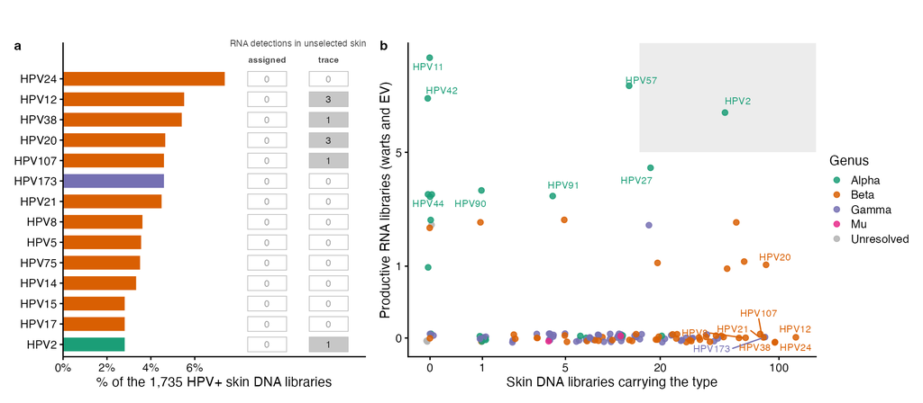

### A Bayesian re-analysis under weakly-informative priors confirms the contrasts

To confirm these conclusions are not artifacts of the frequentist framework or of the near-complete separation in the strongest contrast, we refitted the positivity, depth-controlled detection and productivity models as Bayesian logistic regressions under weakly-informative priors (Normal(0, 2.5) on the log-odds coefficients; Methods), summarizing each effect by its posterior median odds ratio, 95% credible interval (CrI) and posterior probability of direction (Table S3, drawn as a forest plot in Figure S5). The contamination enrichment and the trace excess were reproduced essentially unchanged and with near-certainty (cell-line OR 5.2 [3.6, 7.3], engineered OR 4.6 [2.8, 7.4], neoplasia trace OR 1.9 [1.6, 2.4]; each with P(OR > 1) > 0.999). Crucially, the productive-controls-versus-skin contrast, whose frequentist odds ratio (10,183) is inflated and unstable under separation, regularized to a finite but still enormous posterior OR of 8,785 [2,887, 30,272] (14,515 [3,961, 77,562] under a heavier-tailed Student-*t* prior): the productive gap between warts/EV and skin is real, not a separation artifact. Deeper sequencing within neoplasia again bought no productive-level detection (OR 1.7 [0.2, 16], P(OR > 1) = 0.685), and the warts/EV-versus-neoplasia productivity contrast held (OR 3.7 [1.3, 11], P(OR > 1) = 0.991). The neoplasia-versus-skin comparison at floor level, whose frequentist interval is wide because it rests on 6 above-floor libraries, shrinks under the prior but stays clearly positive (OR 12 [3.7, 39], P(OR > 1) = >0.999): the small floor-level elevation of neoplasia over clean skin is genuine. It is nonetheless negligible beside the near-four-orders-of-magnitude productive-control effect, and it does not alter the trace-not-productive conclusion.

## Discussion

By systematically re-mining public human RNA-seq, recovering the non-human reads that standard transcriptomic pipelines discard, we resolved the productive status of cutaneous HPV across the spectrum from healthy skin to carcinoma, while controlling for the two confounders that have dogged this question: laboratory contamination and sequencing depth. Three findings stand out. First, HPV signal in archived RNA-seq is dominated by cell-line and engineered material and by the integrated mucosal types HPV16/HPV18, so that genuine primary skin carries HPV at only 2–4%. Second, and centrally, HPV in cutaneous neoplasia (cSCC/AK) is present only as a transcriptionally inactive trace, not as productive infection, and this gap is not an artifact of how deeply the libraries were sequenced. Third, the same assay readily detects productive infection where it genuinely occurs: in warts and epidermodysplasia verruciformis (EV), and in a minority of bona fide primary-skin lesions carrying beta- and alpha-HPV.

### Trace, not productive: the transcriptomic phenotype of cutaneous neoplasia

The defining prediction of the “hit-and-run” hypothesis is that beta-HPV acts early in cutaneous carcinogenesis but is dispensable for tumour maintenance (Howley and Pfister 2015). Dispensability is a claim about requirement rather than about persistence, and on its own it predicts nothing about transcription; what it removes is the pressure to retain the genome. Because papillomavirus episomes are maintained only by active tethering to mitotic chromosomes, and are cleared as the cell divides once that tether is lost (You et al. 2004; Fisher 2015), an unselected genome is diluted out of the expanding clone, and it is that step, not dispensability itself, which predicts viral load and transcription minimal or absent in established carcinoma. The experimental backbone of this model is genetic: in transgenic and infection systems, deleting the viral oncogenes after lesions have formed, or transplanting secondary tumours, leaves carcinoma growth unaffected and viral genomes undetectable (Viarisio et al. 2018; Dorfer et al. 2021), and in human tissue viral load and transcription are highest in early precursor lesions and fall in established tumours (Borgogna et al. 2018). Our data provide a complementary, population-scale transcriptomic read-out of the same prediction. Across 406 cSCC/AK libraries, only 6 reached the control-calibrated detection floor (1.5%), against 93.2% of productive controls, and the group’s median burden was 0.012 RPM against 5,408 RPM in controls. Neoplasia does carry HPV more often than clean skin, both as a trace signal (any read; OR 2.0, *P* = 5.5×10⁻¹⁰) and, marginally, at the detection floor (OR 14, *P* = 6.7×10⁻⁶; halved to OR 7.5 once the 3 mucosal HPV16 cases are removed). But that elevation is a rise from near-zero to near-zero, and it is not converted into productive burden by any amount of sequencing. This is the residual footprint, rather than active infection, that hit-and-run predicts. It is not, however, evidence for that model over its competitors, for reasons set out below. This is not a new observation, and we do not present it as one. Transcriptional silence of HPV in cutaneous carcinoma has now been reported from four independent RNA-sequencing series: the original cSCC transcriptome study (Arron et al. 2011), total RNA sequencing of skin lesions at a median 66 million reads (Hultin et al. 2019), whole-transcriptome analysis of 345 post-transplant non-melanoma skin cancers at a median 35 million reads with transcription in 15 (Arroyo Mühr, Hultin, and Dillner 2021), and RNA sequencing of 23 risk-stratified cSCC biopsies with no HPV expression against 64% DNA positivity in the same samples (Vandiver et al. 2021), the DNA-present/RNA-absent dissociation we report here with the paired modality our design cannot supply. An orthogonal assay agrees at comparable cohort size: E6/E7 mRNA in situ hybridization across 243 cutaneous SCC detected high-risk transcripts in 0.9% of the 225 non-anogenital cases (Fujimoto et al. 2019). Two of the sequencing series ran at medians of 35 and 66 million reads, and so had already disposed of the possibility that this negative is an artifact of shallow sequencing. Nor is the literature unanimous: in situ hybridization on PCR-positive transplant-recipient cSCC demonstrated EV-HPV transcripts in 4 of 11 tumours, localized to the mid and upper epidermis (Purdie et al. 2005), a focal, suprabasal signal that bulk sequencing of a whole biopsy averages away and that our design would not recover.

What our data add is not the direction of the result but its denominator, its controls and its criterion. The prior transcriptomic series run from 11 to 345 specimens; ours covers 406 cSCC/AK libraries against 7,800 unselected-skin libraries in the same pipeline, which converts an absence reported within lesions into a case/control contrast with an estimated effect size. The largest prior series is confined to formalin-fixed material from transplant recipients; ours is restricted to neither, so the result is not conditional on immunosuppression or on archival fixation. And where the prior work scores HPV presence or transcription, we score productive replication from late capsid transcripts against a floor calibrated on lesions in which productive infection is certain, so that “no productive infection in cSCC/AK” is measured on the same instrument that reports 93.2% productivity in warts rather than asserted from a null result. The depth argument likewise changes role: it is no longer the discovery that depth was not the explanation, which Arroyo Mühr, Hultin, and Dillner (2021) had already established, but a modeled covariate across that contrast, and the neoplasia libraries were in any case sequenced almost four times more deeply than the productive controls (median 45.2M vs 12.2M reads), with even the deepest, at 327.3M reads, not crossing the productive threshold.

That said, transcriptomic absence cannot by itself adjudicate the mechanism, and the reason is sharper than a general appeal to correlation. The decline of viral activity from healthy skin to carcinoma is not the discriminating observation it was once taken to be, because all three live accounts predict it.

Under hit-and-run, activity falls because a genome that nothing selects for is diluted out of the expanding tumour clone, dispensability being what permits that loss rather than what causes it (Howley and Pfister 2015; Viarisio et al. 2018; Dorfer et al. 2021); the same review literature also proposes that virus-induced recombinogenic activity contributes to the secondary loss of viral genomes from neoplastic cells (Niller, Wolf, and Minarovits 2011), which for beta-HPV would make the DNA-repair abrogation that constitutes the hit part of the mechanism of the run. Under the protective-immunity account, it falls because virus-positive cells are selected against: the original report already showed reduced beta-HPV activity and load in human skin cancer relative to adjacent healthy skin (Strickley et al. 2019), and the mechanism has since been resolved further, with papillomavirus colonization blocking the expansion of mutant p53 clones in a CD8<sup>+</sup> T-cell-dependent manner, beta-HPV activity elevated in sun-exposed human skin bearing such clones, and clonal expansion in premalignant lesions associated with loss of beta-HPV (Son et al. 2025). A falling viral signal along the progression axis is therefore a shared prediction, and our data, which measure exactly that axis, cannot separate the two. That work also reports beta-HPV activity *elevated* in sun-exposed human skin, which sits in apparent tension with the quiet reservoir we describe. The two measurements are not commensurate: theirs is in situ viral activity in the epidermis, localized to keratinocyte clones in UV-damaged skin, whereas ours is a whole-biopsy bulk average over archived libraries with no stratification by UV exposure, and a focal signal confined to a small clonal compartment is precisely what such an average dilutes. Our healthy-skin figure should therefore be read as a population-level transcript abundance in unselected skin, not as a claim that no keratinocyte anywhere is transcribing beta-HPV. We note also that the protective-immunity claim is itself contested in the primary literature, having drawn a Matters Arising and a reply in the same journal (Lambert et al. 2021; Strickley et al. 2021), so presenting it as one settled half of a two-way contest would misdescribe the field.

A third account requires no oncogenic or immunological premise at all. The beta-HPV genome restricts its own gene expression and replication through the viral E8^E2 protein, and immortalization of human keratinocytes by a beta-HPV genome requires that repressor to be inactivated as well as E6, E7, E1 and E2 to be present (Rehm et al. 2022). On that reading, a transcriptionally quiet beta-HPV genome in skin is the virus in its default state, and quiescence carries no information about oncogenic mechanism whatsoever. Our observation that the cutaneous reservoir is episomal and quiet in healthy skin, and remains quiet in neoplasia, is consistent with this without requiring it.

What our data therefore establish is not a verdict between models but the phenomenology all of them must accommodate, measured rather than assumed: established cutaneous neoplasia does not host productive HPV infection. 1.5% of cSCC/AK libraries reach the productive floor, against 93.2% of lesions in which productive infection is certain, and that gap is independent of sequencing depth and of library chemistry. Our cross-sectional snapshot of bulk transcription measures viral activity, not causation, and cannot distinguish a virus that has “hit and run” from one that was selected against by immunity, or from one that was never transcriptionally active to begin with.

One line of evidence does go beyond observation, and it is worth stating precisely what it shows. In a double-blind randomized sham-controlled trial, 70 immunocompetent adults with 15 or more actinic keratoses received a nine-valent papillomavirus vaccine or sham. Lesion-burden reductions were greater in the vaccinated group at 6 and 12 months (47% versus 29%, *P* = 0.01; 58% versus 47%, *P* = 0.05), with fewer thick lesions, and no difference in the rate of new lesions or in keratinocyte-carcinoma incidence over the year (Wenande et al. 2025). This is the interventional experiment a cross-sectional transcriptomic survey cannot perform, and it shows that manipulating papillomavirus immunity changes precancerous lesion burden. It is not evidence that beta-HPV is productively replicating in those lesions, and it does not identify the virus responsible: the vaccine targets nine mucosal alphapapillomavirus types, none of them the cutaneous beta-types that dominate the skin reservoir, so any effect must run through cross-reactive or non-specific immunity rather than through neutralizing the resident virus. Our result is consistent with that reading rather than in tension with it, since an immunological intervention can reduce lesion burden without productive viral replication being present to target.

### Productive cutaneous HPV is real, but it is the property of warts and EV

The trace-level neoplasia result is not a failure of sensitivity. The assay recovered abundant productive infection in the positive-control lesions: 64% of targeted wart/EV libraries met the strict L1 major-capsid criterion, spanning the expected cutaneous repertoire (HPV2/27/57, HPV6/11, and diverse beta/gamma types), consistent with the differentiation-coupled late program that defines productive papillomavirus infection (Doorbar et al. 2012; Egawa and Doorbar 2017). The contrast between productive controls and neoplasia was significant (OR 3.8, *P* = 0.013). A small number of genuine, non-cell-line skin lesions also harbored unambiguous productive infection, most strikingly an HPV12-productive cSCC and two lesions co-infected with the beta types HPV96 and HPV182 at near-complete genome coverage and high depth. These cases matter for two reasons. They confirm that bona fide productive cutaneous beta/gamma infection occurs in primary tissue and can be detected from public RNA-seq, which answers the original descriptive question about productive infection. The companion question about non-traditional tissues is not answered here: every one of these libraries is cutaneous, and the residual group that would have to supply non-cutaneous evidence is defined by missing site metadata rather than by an identified site elsewhere, so this design can bound HPV activity in skin but cannot survey the tissues outside it. They also show that the population-level “trace” conclusion is a statement about the central tendency of cSCC/AK, not a claim that productive cutaneous HPV disease never exists. The picture that emerges aligns with the commensal model of cutaneous HPV (Antonsson et al. 2000; Foulongne et al. 2012): a ubiquitous but transcriptionally quiet beta/gamma reservoir in normal skin, overt productive disease confined to warts and EV, and only a residual footprint in carcinoma.

### What a 2-4% transcriptome prevalence means against a 90% DNA reservoir

Our primary-skin figure of 2-4% sits against a DNA literature reporting cutaneous beta-HPV in the large majority of healthy adults, and the gap is wide enough that it has to be addressed directly rather than filed under limitations. It is not a contradiction, because the two numbers measure different things, and three published quantities show why.

The first is abundance. Quantitative PCR of eyebrow hair follicles across 782 immunocompetent people and organ-transplant recipients found median beta-HPV DNA loads below one viral copy per 60 cells, spanning seven orders of magnitude (S. Weissenborn et al. 2012). A commensal carried at that density is below the detection floor of bulk RNA sequencing by construction: even under perfect transcription, one genome per 60 cells contributes a vanishing fraction of a library’s reads. Most of the DNA assays reporting high prevalence are type-specific PCR amplifications designed to find exactly this, and they are orders of magnitude more sensitive than untargeted sequencing of total RNA; the untargeted metagenomic survey that also reports high skin prevalence sampled skin-surface sites (Ma et al. 2014), which brings in the second difference.

The second is substrate. The standard substrates of cutaneous beta-HPV epidemiology are surface skin swabs and plucked eyebrow hair bulbs, and the choice between them changes the answer: in the same 370 individuals, beta-HPV prevalence was 92% in swabs against 73% in eyebrow hairs, and gamma-HPV 84% against 43% (Rollison, Schell, et al. 2019). Both sample the follicular and superficial compartments where the commensal reservoir resides. Our substrate is neither. Archived RNA-seq libraries are made from biopsy or excision tissue, which is dominated by the dermis and the viable epidermis and largely excludes the surface and follicular material that swabs and hair bulbs are designed to capture. Our 2-4% is therefore a statement about papillomavirus transcript abundance within intra-epidermal biopsy tissue, not an estimate of the reservoir as the DNA literature defines and samples it.

The third is the reference panel. Deep sequencing of human skin has cataloged 396 HPV types, of which 229 were previously unknown (Bzhalava et al. 2014), whereas typing here is anchored on the PaVE reference set of 455 sequences. Types with no reference genome cannot be assigned by any panel-based method, so our prevalence is a floor with respect to cutaneous diversity as well as to abundance, and the trace-level detections that resolve to a confident type (Table S6) are the visible edge of a wider reservoir rather than its full extent.

Read together, these place the 2-4% where it belongs: as the transcriptionally detectable fraction of a reservoir that is genuinely near-ubiquitous at DNA level, and not as a competing prevalence estimate. That distinction matters beyond bookkeeping, because it is the same distinction the paper draws for neoplasia. Prospective work makes the point from the DNA side: among 1,008 individuals followed after baseline skin-swab typing, beta-HPV detection predicted subsequent cutaneous SCC, yet fewer than 5% of the beta-HPV types found on a person’s skin were present in the tumour that person later developed (Rollison et al. 2021). A second cohort, in a different population and with paired sampling by site, reaches the same conclusion: across 193 samples from organ-transplant recipients and immunocompetent patients with cSCC, 65 HPV genotypes were recovered, 56 of them from eyebrow hair against 30 from the carcinomas, and genotype-specific concordance between a patient’s eyebrow hair and their own cSCC was found in 5 of 55 patients (9.1%) (Oh et al. 2026). The commensal reservoir is richer than the tumour and largely not the same virus, which is what our transcriptomic data show at population scale and from the activity side.

### Actinic keratosis, HPV8, and what a bulk transcriptome cannot see

The precursor end of the neoplasia group deserves separate treatment, because a specific hit-and-run mechanism has been built on it. In mouse models, the HPV8 E6 protein binds p300 and phosphorylates STAT3, inducing ΔNp63 and driving proliferation and expansion of Lrig1<sup>+</sup> hair-follicle junctional-zone keratinocyte stem cells into the overlying epidermis; HPV8 was reported in association with 70% of human actinic keratoses, and the authors frame the expansion of these melanosome-poor, UV-vulnerable stem cells as the hit-and-run mechanism itself (Morgan et al. 2024).

On presence, we do not disagree. Trace HPV reads were recovered from 62.5% of our 72 AK libraries, which is the same order as their 70% association figure. Our result concerns what that material is doing, and the answer is the same in AK as in carcinoma: 1 of 72 AK libraries reached the productive floor.

That is not a contradiction of their model, and is closer to a corroboration of it. A mechanism driven by E6 acting on a stem-cell compartment requires viral oncogene function, not capsid production, and a hit-and-run account predicts precisely that the virus leaves no productive footprint in the lesion it helped initiate. Our data supply the population-scale version of that prediction and find it satisfied.

Two things we cannot settle are worth stating plainly. The first is type. We detected no HPV8 anywhere in the cohort: no library met the assignment criterion for it, and it was the best-hit reference in none of the 325 trace-level libraries, although HPV8 is present in the reference panel and other beta-1 types including HPV5 and HPV12 were recovered. Whether that reflects genuine absence of HPV8 transcription, cohort composition, or the fact that DNA association and transcript detection need not coincide, we cannot determine from RNA alone. The DNA side of the same question is not silent, which sharpens rather than resolves it: the independent metagenome catalog places HPV8 in 63 of 1,735 HPV-positive skin libraries, the eighth commonest type in that reservoir (Figure 5 a), against 0 detections at any level here. The type most often named as the cutaneous carcinoma candidate is thus present on skin and, in this cohort, never transcribed above the detection floor. The second is compartment. The Lrig1<sup>+</sup> junctional zone is a follicular structure, and it is exactly the compartment that our substrate under-samples: it is what plucked eyebrow-hair-bulb assays are designed to capture and what an excision biopsy dominated by dermis and interfollicular epidermis dilutes. A focal, follicular, stem-cell-restricted reservoir is the case our design is least able to see, and the negative we report for AK should be read with that limit attached.

### Contamination is the dominant signal in naïve analyses

Our cell-line finding is both a result and a methodological warning. The roughly five-fold enrichment of HPV positivity in cell-line and engineered libraries, dominated by HPV16/HPV18, mirrors the documented contamination of public sequence archives by HeLa-derived and other integrated-HPV reads (Adey et al. 2013; Cantalupo, Katz, and Pipas 2015; Kazemian et al. 2015). Where that contamination has been traced to its source, the mechanism is exactly the one our enrichment implies: applying a virus-detection workflow to 9,143 TCGA RNA-seq libraries from a single sequencing center attributed the HeLa-derived HPV18 signal, and a co-occurring XMRV signal, to a pool of cell lines run alongside the tumours as a quality-control reference, so that the tumours carrying those reads were not infected at all (Selitsky et al. 2020). Our result is the same phenomenon at the scale of the whole archive rather than one center, and without the laboratory metadata that allowed that study to name the culprit. Nor is the problem confined to cell lines: systematically sequencing the laboratory components themselves showed that more than 65% of viral sequences recovered from 712 libraries fell into clusters linked to a reagent or protocol step rather than to the specimen (Asplund et al. 2019), which is why a detection floor calibrated on genuine productive lesions, rather than on the absence of reads, is doing necessary work here. Any survey that pools archived data without flagging non-primary material and without coverage-breadth and depth thresholds will substantially overstate HPV prevalence and mis-attribute mucosal high-risk types to tissues where they have no biological place. The cost of getting this wrong at archive scale is not hypothetical: re-analysis of the reported pan-cancer microbiome found that most of the microbes originally called were not present in the samples at all, invalidating the original report and more than a dozen studies built on it (Gihawi et al. 2023). None of the individual safeguards we applied is novel, and the requirements have been set out before in reviews of virus detection in sequence data (Cantalupo and Pipas 2019). What we contribute is their operationalization and measurement on one cohort: explicit cell-line, engineered and in-vitro annotation, study-level curation, dual breadth-and-depth typing thresholds, a control-calibrated productivity floor, and burden normalized for both depth and library chemistry, with the size of the artifact each is guarding against reported rather than asserted. That combination generalizes beyond HPV.

### What the integration marker measures

Reading integration from the relative abundance of viral genes is not new, and the marker used here should be located against that work rather than presented as an invention. In cervical disease, the ratio of E2 to E6 is an established surrogate for physical integration status: measured on cytology specimens from 226 HPV16-positive women it falls with lesion grade, from 0.79 in both normal epithelium and CIN1 to 0.48 in CIN2/3 and 0.36 in carcinoma, discriminating CIN2 or worse with an area under the curve of 0.844, and it declines alongside L1 capsid immunoreactivity (Choi et al. 2018). The underlying biology, that the integrated fraction rises with lesion severity, is older still (Cheung et al. 2008). The step from DNA ratios to transcript ratios has also been taken: integration status in head and neck squamous carcinoma has been classified from spliced virus-host fusion transcripts and from ratios of HPV gene transcripts across 261 RNA-seq samples in five cohorts, with DNA integration events in 102 participants as ground truth (Li et al. 2026). The more general move, grading integration by its transcriptional output rather than its presence, is also established: in cervical cancer, integration sites that generate fusion transcripts behave differently from silent ones, and the productive fraction rises from carcinoma in situ to advanced disease (Fan et al. 2023). Our cervical validation series reproduces that direction from a different measurement, which is a point in its favor rather than a novelty claim. What is specific to this study is narrower than the concept: an E1 numerator against an E2 denominator taken from bulk RNA-seq read counts, applied to cutaneous beta- and gamma-types in skin, and used as a provenance check rather than a clinical classifier. Even so, a marker that only ever fired on cultured cells would be indistinguishable from the metadata-based flagging it was meant to check independently. The graded cervical series settles that question in the direction that matters. Across HPV16-positive normal epithelium, high-grade lesion and carcinoma, sequenced under one protocol and labeled by the submitting study, the ratio moves monotonically with grade in primary tissue with no cell line anywhere in the series, and late transcription falls away along the same axis. The marker is therefore reading integration as a biological process rather than culture as a provenance, which is what licenses its use on skin: when it reports the cutaneous reservoir as episomal and quiet, that is a statement about the virus, not an echo of how the libraries were annotated. The series is small, and the normal-epithelium arm in particular rests on few informative libraries, so it establishes the direction of the marker rather than a calibrated scale. A second and more consequential limit comes from the cervical literature that established the ratio in the first place. An E2 deficit is not specific to advanced disease: triplex quantitative PCR for E6, E2 and beta-globin indicated integration in 44.3% of histologically negative control samples in a series of 380 women, with substantial overlap between cases and controls that precluded any usable cutoff (Boulet et al. 2009), and serial sampling of women recruited soon after first intercourse showed E2 disruption to be a common and early event in incident infection, occurring within months and more often for HPV18 than HPV16 (Collins et al. 2009). Our inferential chain runs from a high E1:E2 to an episomal reservoir, and that chain is only as strong as the specificity of the deficit it inverts. One difference works in our favor without settling the matter: those studies measure DNA copy-number ratios, in which a minor integrated subclone can depress the ratio while the bulk population remains episomal, whereas we measure transcript ratios, which report what the viral population is actually expressing. Whether that makes the transcript form less susceptible to the early-integration confound is a reasonable expectation rather than something demonstrated here, and until it is tested the marker should be read as evidence about the dominant transcriptional state of the reservoir, not as a proof that no integrated genome is present. It is also worth being explicit about what the cervical data are not doing here. They are not a matched mucosal counterpart to the skin cohort, and the two are not contrasted quantitatively: the comparison that carries weight is within the cervical progression itself, where the confounders that separate any two archived cohorts, depth, protocol, selection and provenance, are held constant by design.

### What a petabase catalog does and does not measure

The DNA axis used here is a catalog, and catalogs answer a narrower question than they appear to. The Logan-wide papillomavirus survey identifies contigs by profile-HMM filtering with identification of the conserved L1 B and I domains (J. Y. Q. Shen et al. 2026), over an assembly of 27 million archived sequencing libraries (Chikhi et al. 2024), so a contig enters the catalog because it carries a detectable L1. Three consequences follow, and together they bound what any comparison against such a resource can claim. First, presence in the catalog means L1-detectable presence, and carries no information about the state of the viral genome. Second, the catalog is assembly-based, and an integrated genome cannot assemble across the virus-host junction, so integrated molecules are systematically under-recovered: conditioning on near-complete contigs returns an intact E2 in 99.3% of cervical carcinoma contigs against 99.9% in skin (Table S8), which is close to a tautology rather than a biological result, because the completeness criterion has already selected episomal genomes in both. Third, because every contig is anchored on L1 and extends outward from it, the frequency with which an open reading frame is truncated at a contig terminus tracks its distance from that anchor rather than the position of any breakpoint; the ordering E1 > E2 > L1 holds in every body site examined, including healthy vaginal and gut carriage, where integration cannot explain it. Genome state therefore has to be read from reads or from transcription rather than from catalog membership, which is what the E1:E2 ratio and the virus-host junctions do above. The point generalizes beyond papillomaviruses: petabase-scale surveys are now the standard way to establish that a virus is present in a body site, and a presence count from such a survey is not evidence of an active infection. Within those bounds the catalog is exactly the right instrument for the one job it is given here. Read as presence and nothing more, it establishes independently of our pipeline, our modality and our cohort that the cutaneous beta/gamma reservoir this survey reports as quiet is really there, in the expected genera and the expected types (Figure 5), so the negative result is a statement about activity rather than about whether the virus was present to be transcribed. The two arms nonetheless sample different compartments, surface swabs against bulk tissue, as set out above; that difference bounds any quantitative comparison between them, which is why the reservoir is used here as corroboration of presence and never as a denominator for the transcriptional rate.

### Strengths and limitations

The principal strengths of this work are its scale, its uniform end-to-end processing of heterogeneous public data, and its explicit control of the depth, chemistry and contamination confounders that limit prior reports. Recovering discarded non-human reads turns a vast existing resource toward a question it was never collected to answer (Edgar et al. 2022), and reading productivity directly from the early/late transcript program provides a biologically grounded activity measure rather than mere presence/absence. That last point is where this work sits relative to the two prior archive-scale mining studies of skin. Screening off-target reads across 19 skin tumour types was a search for a driver, and found one, in an acral tumour outside the beta-HPV question entirely (Leiendecker et al. 2023); reprocessing 8,274 public skin libraries cataloged HPV among the foreign RNA of skin without typing it, scoring its productivity or setting it against a case/control design (Bhargava et al. 2025). Both establish that the substrate is rich. Neither asks, and neither can answer, at what rate cutaneous HPV is transcribed across the spectrum from healthy skin to carcinoma and whether that transcription is productive, which is the question this study is built around.

Several limitations temper interpretation. First, the unbiased prevalence sweep screened 11,556 libraries, a large but not exhaustive sample of public human skin RNA-seq: of roughly 12,200 candidate runs discovered, the remainder were lost to withdrawn accessions, download failures or quality-control exclusion, and archival sampling is itself non-random, so the absolute healthy-skin positivity rate is best read as an estimate. Second, library-selection chemistry biases viral recovery, and although we measured it rather than assuming it away, we could not measure it everywhere. Chemistry was resolvable for 62.2% of libraries; for the remainder the SRA record and the submitted protocol text are both silent, and those libraries carry the trace signal alongside the resolved ones. Where it is known, the axis of concern is flat: rRNA-depleted libraries were no more likely than poly-A libraries to carry an HPV read at equal depth (OR 1.0, 0.8–1.2), and the group reported here as non-productive is the one more often built with the favorable chemistry. What this does not settle is the rest of library construction. Selection chemistry is only one axis: input amount, RNA integrity and fragment-size selection are not recoverable from archived metadata at all, and a poly-A-selected library remains, in principle, a conservative instrument for late viral transcripts. Absence of HPV reads is therefore not proof of absence of virus, and our productivity estimates remain conservative. Third, bulk sequencing of a whole biopsy averages over every cell in it, so transcription confined to a small, focal cell fraction is diluted below detection. This is not hypothetical for cutaneous HPV: in situ hybridization localizes EV-HPV transcripts to the mid and upper epidermal layers of cSCC (Purdie et al. 2005), precisely the spatially restricted, suprabasal pattern that a whole-biopsy average is least able to see. Our productivity estimates are therefore a lower bound on focal transcription, and the negative we report is a statement about population-level viral burden rather than about every cell in every tumour. Fourth, tissue and diagnosis labels were derived programmatically from sample metadata and are imperfect, despite curation; residual misclassification adds noise to the group assignments. Fifth, typing is anchored on a fixed reference panel, and deep sequencing of skin has described 229 HPV types that had no reference genome at the time of that survey (Bzhalava et al. 2014); such types are invisible to any panel-based assignment, so our type catalog and prevalence are bounded by the panel as well as by detection sensitivity. Sixth, the high sequence similarity among HPV types permits cross-mapping, which we mitigated with breadth/depth thresholds and multimapping-aware alignment but cannot wholly exclude; the same caveat attaches to distinguishing low-level true infection from residual contaminant signal at the detection floor, although the transcripts themselves bound the problem: decomposing the below-floor libraries by gene shows that 63% carry no reads on any HPV gene and are best read as a k-mer and cross-mapping floor, while a minority carry early-gene transcripts without the late program, the signature of latent or abortive infection, on cutaneous rather than mucosal types (Figure S2). The sub-threshold trace is therefore neither wholly artifactual nor productive. Seventh, our data are transcriptomic and cross-sectional: we cannot observe viral DNA persistence, integration state, or the temporal decline in viral activity that the hit-and-run model specifies, and we therefore describe the productive-status phenomenology rather than prove the mechanism. Finally, the L1-based productivity rule, while deliberately stringent, depends on beta/gamma gene annotation quality and treats integrated-line L1 signal cautiously (reported only in the supplement).

### Conclusion

Mining the reads that transcriptomic studies routinely throw away, we find that the cutaneous HPV reservoir of healthy skin is real but transcriptionally quiet, that productive cutaneous HPV infection is the property of warts and EV, and that HPV in cutaneous squamous neoplasia, at population scale and independent of both sequencing depth and library chemistry, is a trace, non-productive footprint rather than an active infection. This transcriptomic phenotype is the common ground that every current account of beta-HPV in skin cancer must explain, whether the virus is a departed cofactor, the target of protective immunity, or a genome that is transcriptionally restricted by default. Because a declining viral signal is predicted by all three, separating them will not be achieved by measuring viral activity more precisely. It will require designs that break the shared prediction: matched DNA- and RNA-level profiling across the precursor-to-carcinoma transition, resolution of where the residual virus resides relative to mutant clones and to infiltrating T cells, linkage to host antiviral immunity in the same tissue, and interventional studies of the kind the VAXAK trial has now begun (Wenande et al. 2025). The single-cell assay is not itself the missing piece: HPV transcripts have already been resolved to basal keratinocytes, suprabasal keratinocytes and hair-follicle stem cells within a cutaneous lesion by single-cell RNA sequencing (Devitt et al. 2019). What has not been done is to apply it at cohort scale across the actinic-keratosis-to-carcinoma transition in beta- and gamma-positive lesions, which is where a shared prediction of declining activity would finally come apart into distinguishable ones. The public-archive mining framework developed here, with its contamination controls and its normalization for both depth and library chemistry, provides a scalable foundation for identifying the cohorts worth taking to that resolution.

## Affiliations

1. Institute of Biomedicine and Translational Medicine, University of Tartu, Tartu, Estonia
2. Institute of Bioengineering, University of Tartu, Tartu, Estonia

Taavi Päll<sup>1</sup>, Alla Piirsoo<sup>2</sup>, Marko Piirsoo<sup>2</sup>

Correspondence: Taavi Päll, Institute of Biomedicine and Translational Medicine, Biomeedikum, Ravila 19, 50411 Tartu, Estonia. Email: taavi.pall@ut.ee. Telephone: +372 737 4185

## ORCiDs

Taavi Päll: https://orcid.org/0000-0001-7606-675X

Alla Piirsoo: https://orcid.org/0000-0001-6843-7127

## Ethics Statement

This study analyzed only publicly archived, de-identified human sequencing data retrieved from the NCBI Sequence Read Archive, and generated no new human or animal material. Institutional review board approval and informed consent were therefore not required for the work reported here. Ethical approval and participant consent for the primary studies were the responsibility of their submitting investigators and are recorded in the corresponding BioProject entries.

## Data Availability Statement

The complete analysis pipeline, comprising the Nextflow workflow, the per-process software environments and container definitions, the reference-construction and SRA-discovery scripts, and the downstream R analysis and statistical-inference code, is openly available at https://github.com/tpall/hpv-human-skin. All sequencing data analyzed here are public and were obtained from the NCBI Sequence Read Archive; the per-cohort lists of accessions (SRR/SRX), with assigned tissue category, diagnosis, and cell-line/engineered annotations, are provided as Supplementary Data. Reference genomes were retrieved from the Papillomavirus Episteme (PaVE; https://pave.niaid.nih.gov) and NCBI RefSeq. No new sequencing data were generated.

## Conflict of Interest

The authors state no conflict of interest.

## Acknowledgments

This research was supported by the Estonian Research Council grant (PRG2707).

This research was co-financed through the DURABLE project. The DURABLE project has been co-funded by the European Union, under the EU4Health Programme (EU4H), Project no. 101102733. Views and opinions expressed are however those of the authors only and do not necessarily reflect those of the European Union or the European Health and Digital Executive Agency. Neither the European Union nor the granting authority can be held responsible for them.

The computations were performed on the High Performance Computing Center of the University of Tartu. We thank the submitting investigators of the studies re-analyzed here, whose deposition of raw sequencing data to public archives made this work possible.

## Declaration of Generative AI Use

During this work the authors used Claude (Anthropic) to assist with writing and debugging the analysis pipeline and statistical code, and with editing the manuscript text, and Microsoft Copilot to help draft review comments on the manuscript. The authors reviewed and edited all output and take full responsibility for the content of the publication.

## References

Adey, Andrew, Joshua N. Burton, Jacob O. Kitzman, Joseph B. Hiatt, Alexandra P. Lewis, Beth K. Martin, Ruolan Qiu, Choli Lee, and Jay Shendure. 2013. “The Haplotype-Resolved Genome and Epigenome of the Aneuploid HeLa Cancer Cell Line.” *Nature* 500: 207–11. https://doi.org/10.1038/nature12064.

Antonsson, Annika, Ola Forslund, Henrik Ekberg, Gunnar Sterner, and Bo G. Hansson. 2000. “The Ubiquity and Impressive Genomic Diversity of Human Skin Papillomaviruses Suggest a Commensalic Nature of These Viruses.” *Journal of Virology* 74 (24): 11636–41. https://doi.org/10.1128/JVI.74.24.11636-11641.2000.

Arron, Sarah T., J. Graham Ruby, Eric Dybbro, Don Ganem, and Joseph L. DeRisi. 2011. “Transcriptome Sequencing Demonstrates That Human Papillomavirus Is Not Active in Cutaneous Squamous Cell Carcinoma.” *Journal of Investigative Dermatology* 131 (8): 1745–53. https://doi.org/10.1038/jid.2011.91.

Arroyo Mühr, Laila Sara, Emilie Hultin, and Joakim Dillner. 2021. “Transcription of Human Papillomaviruses in Nonmelanoma Skin Cancers of the Immunosuppressed.” *International Journal of Cancer* 149 (6): 1341–47. https://doi.org/10.1002/ijc.33683.

Asplund, Maria, Kristín R. Kjartansdóttir, Sarah Mollerup, Lasse Vinner, Helena Fridholm, Jose A. R. Herrera, Jens Friis-Nielsen, et al. 2019. “Contaminating Viral Sequences in High-Throughput Sequencing Viromics: A Linkage Study of 700 Sequencing Libraries.” *Clinical Microbiology and Infection* 25 (10): 1277–85. https://doi.org/10.1016/j.cmi.2019.04.028.

Bhargava, Devika, Alexandra Labadie, Rachel L. Hanson-Rios-Stutz, Austin Goodyke, Emily M. Moses, Amrita S. Das, Sarah Vanderweele, et al. 2025. “From Castaways to Discoveries: Unveiling Treasures in Skin RNAseq Using a Novel Multidimensional Data Processing Workflow Including Infection-Host Dynamics.” *Physiological Genomics* 57 (5): 343–56. https://doi.org/10.1152/physiolgenomics.00093.2024.

Borgogna, Cinzia, Simone Lanfredini, Alberto Peretti, Marco De Andrea, Elisa Zavattaro, Enrico Colombo, Marco Quaglia, et al. 2014. “Improved Detection Reveals Active $\beta$-Papillomavirus Infection in Skin Lesions from Kidney Transplant Recipients.” *Modern Pathology* 27: 1101–15.

Borgogna, Cinzia, Carlotta Olivero, Simone Lanfredini, Federica Calati, Marco De Andrea, Elisa Zavattaro, Paola Savoia, et al. 2018. “$\beta$-HPV Infection Correlates with Early Stages of Carcinogenesis in Skin Tumors and Patient-Derived Xenografts from a Kidney Transplant Recipient Cohort.” *Frontiers in Microbiology* 9: 117. https://doi.org/10.3389/fmicb.2018.00117.

Boulet, Gaëlle A. V., Ina H. Benoy, Christophe E. Depuydt, Caroline A. J. Horvath, Marc Aerts, Niel Hens, Annie J. Vereecken, and Johannes J. Bogers. 2009. “Human Papillomavirus 16 Load and E2/E6 Ratio in HPV16-Positive Women: Biomarkers for Cervical Intraepithelial Neoplasia $\geq$2 in a Liquid-Based Cytology Setting?” *Cancer Epidemiology, Biomarkers & Prevention* 18 (11): 2992–99. https://doi.org/10.1158/1055-9965.EPI-09-0025.

Bzhalava, Davit, Laila Sara Arroyo Mühr, Camilla Lagheden, Johanna Ekström, Ola Forslund, Joakim Dillner, and Emilie Hultin. 2014. “Deep Sequencing Extends the Diversity of Human Papillomaviruses in Human Skin.” *Scientific Reports* 4: 5807. https://doi.org/10.1038/srep05807.

Bzhalava, Davit, Carina Eklund, and Joakim Dillner. 2015. “International Standardization and Classification of Human Papillomavirus Types.” *Virology* 476: 341–44.

Cantalupo, Paul G., Joshua P. Katz, and James M. Pipas. 2015. “HeLa Nucleic Acid Contamination in The Cancer Genome Atlas Leads to the Misidentification of Human Papillomavirus 18.” *Journal of Virology* 89 (8): 4051–57. https://doi.org/10.1128/JVI.03365-14.

Cantalupo, Paul G., and James M. Pipas. 2019. “Detecting Viral Sequences in NGS Data.” *Current Opinion in Virology* 39: 41–48. https://doi.org/10.1016/j.coviro.2019.07.010.

Chen, Shifu, Yanqing Zhou, Yaru Chen, and Jia Gu. 2018. “Fastp: An Ultra-Fast All-in-One FASTQ Preprocessor.” *Bioinformatics* 34 (17): i884–90. https://doi.org/10.1093/bioinformatics/bty560.

Cheung, Jo L. K., T. H. Cheung, Julian W. T. Tang, and Paul K. S. Chan. 2008. “Increase of Integration Events and Infection Loads of Human Papillomavirus Type 52 with Lesion Severity from Low-Grade Cervical Lesion to Invasive Cancer.” *Journal of Clinical Microbiology* 46 (4): 1356–62. https://doi.org/10.1128/JCM.01785-07.

Chikhi, Rayan, Brice Raffestin, Anton Korobeynikov, Robert Edgar, and Artem Babaian. 2024. “Logan: Planetary-Scale Genome Assembly Surveys Life’s Diversity.” *bioRxiv*. https://doi.org/10.1101/2024.07.30.605881.

Choi, Youn Jin, Ahwon Lee, Tae Jung Kim, Hyun Tak Jin, Yong Bok Seo, Jong Sup Park, and Sung Jong Lee. 2018. “E2/E6 Ratio and L1 Immunoreactivity as Biomarkers to Determine HPV16-Positive High-Grade Squamous Intraepithelial Lesions (CIN2 and 3) and Cervical Squamous Cell Carcinoma.” *Journal of Gynecologic Oncology* 29 (3): e38. https://doi.org/10.3802/jgo.2018.29.e38.

Collins, Stuart I., Christothea Constandinou-Williams, Kaisheng Wen, Lawrence S. Young, Sally Roberts, Paul G. Murray, and Ciaran B. J. Woodman. 2009. “Disruption of the E2 Gene Is a Common and Early Event in the Natural History of Cervical Human Papillomavirus Infection: A Longitudinal Cohort Study.” *Cancer Research* 69 (9): 3828–32. https://doi.org/10.1158/0008-5472.CAN-08-3099.

Danecek, Petr, James K. Bonfield, Jennifer Liddle, John Marshall, Valeriu Ohan, Martin O. Pollard, Andrew Whitwham, et al. 2021. “Twelve Years of SAMtools and BCFtools.” *GigaScience* 10 (2): giab008. https://doi.org/10.1093/gigascience/giab008.

Devitt, Katharina, Sarah J. Hanson, Zewen K. Tuong, Erin McMeniman, H. Peter Soyer, Ian H. Frazer, and Samuel W. Lukowski. 2019. “Single-Cell RNA Sequencing Reveals Cell Type-Specific HPV Expression in Hyperplastic Skin Lesions.” *Virology* 537: 14–19. https://doi.org/10.1016/j.virol.2019.08.007.

Di Tommaso, Paolo, Maria Chatzou, Evan W. Floden, Pablo Prieto Barja, Emilio Palumbo, and Cedric Notredame. 2017. “Nextflow Enables Reproducible Computational Workflows.” *Nature Biotechnology* 35 (4): 316–19. https://doi.org/10.1038/nbt.3820.

Dobin, Alexander, Carrie A. Davis, Felix Schlesinger, Jorg Drenkow, Chris Zaleski, Sonali Jha, Philippe Batut, Mark Chaisson, and Thomas R. Gingeras. 2013. “STAR: Ultrafast Universal RNA-seq Aligner.” *Bioinformatics* 29 (1): 15–21. https://doi.org/10.1093/bioinformatics/bts635.

Doorbar, John. 2023. “The Human Papillomavirus Twilight Zone: Latency, Immune Control and Subclinical Infection.” *Tumour Virus Research* 16: 200268.

Doorbar, John, Wim Quint, Lawrence Banks, Ignacio G. Bravo, Mark Stoler, Thomas R. Broker, and Margaret A. Stanley. 2012. “The Biology and Life-Cycle of Human Papillomaviruses.” *Vaccine* 30 (Suppl 5): F55–70.

Dorfer, Sonja, Katharina Strasser, Georg Schröckenfuchs, Michael Bonelli, Wolfgang Bauer, Harald Kittler, Christophe Cataisson, Michael B. Fischer, Beate M. Lichtenberger, and Alessandra Handisurya. 2021. “MmuPV1 Is a Key Driver of Skin Cancer Development Upon Immunosuppression.” *American Journal of Transplantation* 21 (2): 525–39.

Edgar, Robert C., Brie Taylor, Victor Lin, Tomer Altman, Pierre Barbera, Dmitry Meleshko, Dan Lohr, et al. 2022. “Petabase-Scale Sequence Alignment Catalyses Viral Discovery.” *Nature* 602: 142–47. https://doi.org/10.1038/s41586-021-04332-2.

Egawa, Nagayasu, and John Doorbar. 2017. “The Low-Risk Papillomaviruses.” *Virus Research* 231: 119–27.

Fan, Junpeng, Yu Fu, Wenju Peng, Xiong Li, Yuanming Shen, Ensong Guo, Funian Lu, et al. 2023. “Multi-Omics Characterization of Silent and Productive HPV Integration in Cervical Cancer.” *Cell Genomics* 3 (1): 100211. https://doi.org/10.1016/j.xgen.2022.100211.

Fisher, Chris. 2015. “Recent Insights into the Control of Human Papillomavirus (HPV) Genome Stability, Loss, and Degradation.” *Journal of Clinical Medicine* 4 (2): 204–30. https://doi.org/10.3390/jcm4020204.

Foulongne, Vincent, Virginie Sauvage, Charles Hebert, Olivier Dereure, Justine Cheval, Meriadeg Ar Gouilh, Kevin Pariente, et al. 2012. “Human Skin Microbiota: High Diversity of DNA Viruses Identified on the Human Skin by High-Throughput Sequencing.” *PLoS ONE* 7 (6): e38499.

Fujimoto, Masakazu, Ibu Matsuzaki, Yuki Takahashi, Yuichi Iwahashi, Kenji Warigaya, Fumiyoshi Kojima, Masatoshi Jinnin, and Shin-ichi Murata. 2019. “High-Risk Human Papillomavirus E6/E7 mRNA Is Rarely Detected in Nonanogenital Cutaneous Squamous Cell Carcinoma: An RNA in Situ Hybridization-Based Tissue Microarray Study.” *The American Journal of Dermatopathology* 41 (3): 205–10. https://doi.org/10.1097/DAD.0000000000001289.

Gihawi, Abraham, Yuchen Ge, Jennifer Lu, Daniela Puiu, Amanda Xu, Colin S. Cooper, Daniel S. Brewer, Mihaela Pertea, and Steven L. Salzberg. 2023. “Major Data Analysis Errors Invalidate Cancer Microbiome Findings.” *mBio* 14 (5): e0160723. https://doi.org/10.1128/mbio.01607-23.

Goodrich, Ben, Jonah Gabry, Imad Ali, and Sam Brilleman. 2024. *rstanarm: Bayesian Applied Regression Modeling via Stan*. https://mc-stan.org/rstanarm/.

Graham, Sheila V. 2017. “The Human Papillomavirus Replication Cycle, and Its Links to Cancer Progression: A Comprehensive Review.” *Clinical Science* 131 (17): 2201–21.

Howley, Peter M., and Herbert J. Pfister. 2015. “Beta Genus Papillomaviruses and Skin Cancer.” *Virology* 479-480: 290–96.

Hultin, Emilie, Laila Sara Arroyo Mühr, Camilla Lagheden, and Joakim Dillner. 2019. “HPV Transcription in Skin Tumors.” *PLOS ONE* 14 (5): e0217942. https://doi.org/10.1371/journal.pone.0217942.

Johansson, Cecilia, and Stefan Schwartz. 2013. “Regulation of Human Papillomavirus Gene Expression by Splicing and Polyadenylation.” *Nature Reviews Microbiology* 11: 239–51.

Jong, Sarah J. de, Elias Imahorn, Peter Itin, Jouni Uitto, Gérard Orth, Emmanuelle Jouanguy, Jean-Laurent Casanova, and Bettina Burger. 2018. “Epidermodysplasia Verruciformis: Inborn Errors of Immunity to Human Beta-Papillomaviruses.” *Frontiers in Microbiology* 9: 1222.

Jong, Sarah Jill de, Amandine Créquer, Irina Matos, David Hum, Vignesh Gunasekharan, Lazaro Lorenzo, Fabienne Jabot-Hanin, et al. 2018. “The Human CIB1–EVER1–EVER2 Complex Governs Keratinocyte-Intrinsic Immunity to $\beta$-Papillomaviruses.” *Journal of Experimental Medicine* 215 (9): 2289–2310. https://doi.org/10.1084/jem.20170308.

Kazemian, Majid, Min Ren, Jian-Xin Lin, Wei Liao, Rosanne Spolski, and Warren J. Leonard. 2015. “Possible Human Papillomavirus 38 Contamination of Endometrial Cancer RNA-sequencing Samples in TCGA.” *Journal of Virology* 89 (17): 8967–73. https://doi.org/10.1128/JVI.00822-15.

Klymenko, Tetyana, Helena Hernandez-Lopez, Andrew I. MacDonald, Jason M. Bodily, and Sheila V. Graham. 2017. “RNA-Seq Analysis of Differentiated Keratinocytes Reveals a Massive Response to Late Events During Human Papillomavirus 16 Infection.” *Journal of Virology* 91 (24): e01001–17.

Lambert, Paul F., Karl Münger, Frank Rösl, Daniel Hasche, and Massimo Tommasino. 2021. “Beta Human Papillomaviruses and Skin Cancer.” *Nature* 588 (7838): E20–21. https://doi.org/10.1038/s41586-020-3023-0.

Lazarczyk, Maciej, Christian Pons, José-Andrès Mendoza, Patricia Cassonnet, Yves Jacob, and Michel Favre. 2008. “Regulation of Cellular Zinc Balance as a Potential Mechanism of EVER-Mediated Protection Against Pathogenesis by Cutaneous Oncogenic Human Papillomaviruses.” *Journal of Experimental Medicine* 205 (1): 35–42.

Leiendecker, Lukas, Tobias Neumann, Pauline S. Jung, Shona M. Cronin, Thomas L. Steinacker, Alexander Schleiffer, Michael Schutzbier, et al. 2023. “Human Papillomavirus 42 Drives Digital Papillary Adenocarcinoma and Elicits a Germ Cell-Like Program Conserved in HPV-Positive Cancers.” *Cancer Discovery* 13 (1): 70–84. https://doi.org/10.1158/2159-8290.CD-22-0489.

Leinonen, Rasko, Hideaki Sugawara, and Martin Shumway. 2011. “The Sequence Read Archive.” *Nucleic Acids Research* 39 (Database issue): D19–21. https://doi.org/10.1093/nar/gkq1019.

Li, Shiting, Shaomiao Xia, Maria Lawas, Aishani Kulshreshtha, Bailey F. Garb, Sarah E. Soppe, Chamila Perera, et al. 2026. “HPV Integration in Head and Neck Cancer: Downstream Splicing Events and Expression Ratios Linked with Poor Outcomes.” *Clinical Cancer Research* 32 (3): 581–95. https://doi.org/10.1158/1078-0432.CCR-25-0645.

Liao, Yang, Gordon K. Smyth, and Wei Shi. 2014. “featureCounts: An Efficient General Purpose Program for Assigning Sequence Reads to Genomic Features.” *Bioinformatics* 30 (7): 923–30. https://doi.org/10.1093/bioinformatics/btt656.

Ma, Yingfei, Ramana Madupu, Ulas Karaoz, Carlos W. Nossa, Liying Yang, Shibu Yooseph, Patrick S. Yachimski, Eoin L. Brodie, Karen E. Nelson, and Zhiheng Pei. 2014. “Human Papillomavirus Community in Healthy Persons, Defined by Metagenomics Analysis of Human Microbiome Project Shotgun Sequencing Data Sets.” *Journal of Virology* 88 (9): 4786–97. https://doi.org/10.1128/JVI.00093-14.

Meyers, Jordan M., Aayushi Uberoi, Miranda Grace, Paul F. Lambert, and Karl Münger. 2017. “Cutaneous HPV8 and MmuPV1 E6 Proteins Target the NOTCH and TGF-$\beta$ Tumor Suppressors to Inhibit Differentiation and Sustain Keratinocyte Proliferation.” *PLoS Pathogens* 13 (1): e1006171.

Moody, Cary A., and Laimonis A. Laimins. 2010. “Human Papillomavirus Oncoproteins: Pathways to Transformation.” *Nature Reviews Cancer* 10 (8): 550–60.

Morgan, Huw J., Carlotta Olivero, Boris Y. Shorning, Alex Gibbs, Alexandra L. Phillips, Lokapriya Ananthan, Annabelle Xiao Hui Lim, et al. 2024. “HPV8-Induced STAT3 Activation Led Keratinocyte Stem Cell Expansion in Human Actinic Keratoses.” *JCI Insight* 9 (15): e177898. https://doi.org/10.1172/jci.insight.177898.

Niller, Hans Helmut, Hans Wolf, and Janos Minarovits. 2011. “Viral Hit and Run-Oncogenesis: Genetic and Epigenetic Scenarios.” *Cancer Letters* 305 (2): 200–217. https://doi.org/10.1016/j.canlet.2010.08.007.

Nunes, Emily M., Vanesa Talpe-Nunes, and Laura Sichero. 2018. “Epidemiology and Biology of Cutaneous Human Papillomavirus.” *Clinics* 73 (suppl 1): e489s.

Oh, Choon Chiat, Gek San Tan, Jeremy Wee Kiat Ng, Tony Kiat Hon Lim, Fan Foon Cheo, Po Yin Tang, N. Gopalakrishna Iyer, et al. 2026. “Human Papillomavirus Diversity in Asian Individuals with Cutaneous Squamous Cell Carcinoma.” *JAMA Dermatology* 162 (5): 509–14. https://doi.org/10.1001/jamadermatol.2026.0308.

Orth, Gérard. 2006. “Genetics of Epidermodysplasia Verruciformis: Insights into Host Defense Against Papillomaviruses.” *Seminars in Immunology* 18 (6): 362–74.

Purdie, Karin J., Tharsi Surentheran, Jane C. Sterling, Lucy Bell, Jane M. McGregor, Charlotte M. Proby, Catherine A. Harwood, and Judith Breuer. 2005. “Human Papillomavirus Gene Expression in Cutaneous Squamous Cell Carcinomas from Immunosuppressed and Immunocompetent Individuals.” *Journal of Investigative Dermatology* 125 (1): 98–107. https://doi.org/10.1111/j.0022-202X.2005.23635.x.

Ramoz, Nicolas, Luiz-Alberto Rueda, Bakar Bouadjar, Luz-Stella Montoya, Gérard Orth, and Michèle Favre. 2002. “Mutations in Two Adjacent Novel Genes Are Associated with Epidermodysplasia Verruciformis.” *Nature Genetics* 32 (4): 579–81. https://doi.org/10.1038/ng1044.

Rehm, Tina M., Elke Straub, Thomas Iftner, and Frank Stubenrauch. 2022. “Restriction of Viral Gene Expression and Replication Prevents Immortalization of Human Keratinocytes by a Beta-Human Papillomavirus.” *Proceedings of the National Academy of Sciences* 119 (11): e2118930119. https://doi.org/10.1073/pnas.2118930119.

Rollison, Dana E., Rossybelle P. Amorrortu, Yayi Zhao, Jane L. Messina, Michael J. Schell, Neil A. Fenske, Basil S. Cherpelis, et al. 2021. “Cutaneous Human Papillomaviruses and the Risk of Keratinocyte Carcinomas.” *Cancer Research* 81 (17): 4628–38. https://doi.org/10.1158/0008-5472.CAN-21-0805.

Rollison, Dana E., Michael J. Schell, Neil A. Fenske, Basil Cherpelis, Jane L. Messina, Anna R. Giuliano, Pearlie K. Epling-Burnette, et al. 2019. “Cutaneous Viral Infections Across 2 Anatomic Sites Among a Cohort of Patients Undergoing Skin Cancer Screening.” *The Journal of Infectious Diseases* 219 (5): 711–22. https://doi.org/10.1093/infdis/jiy577.

Rollison, Dana E., Daniele Viarisio, Rossybelle P. Amorrortu, Tarik Gheit, and Massimo Tommasino. 2019. “An Emerging Issue in Oncogenic Virology: The Role of Beta Human Papillomavirus Types in the Development of Cutaneous Squamous Cell Carcinoma.” *Journal of Virology* 93 (7): e01003–18. https://doi.org/10.1128/JVI.01003-18.

Saeidian, Amir Hossein, Leila Youssefian, Mahtab Naji, Hamidreza Mahmoudi, Samantha M. Barnada, Charles Huang, Karim Naghipoor, et al. 2023. “Whole Transcriptome–Based Skin Virome Profiling in Typical Epidermodysplasia Verruciformis Reveals $\alpha$-, $\beta$-, and $\gamma$-HPV Infections.” *JCI Insight* 8 (5): e162558. https://doi.org/10.1172/jci.insight.162558.

Selitsky, Sara R., David Marron, Daniel Hollern, Lisle E. Mose, Katherine A. Hoadley, Corbin Jones, Joel S. Parker, Dirk P. Dittmer, and Charles M. Perou. 2020. “Virus Expression Detection Reveals RNA-Sequencing Contamination in TCGA.” *BMC Genomics* 21 (1): 79. https://doi.org/10.1186/s12864-020-6483-6.

Shen, Jessica Y. Q., Rayan Chikhi, Anton Korobeynikov, and Artem Babaian. 2026. “Petabase-Scale Papillomavirus Discovery.” *bioRxiv*. https://doi.org/10.64898/2026.04.21.719858.

Shen, Wei, Shuai Le, Yan Li, and Fuquan Hu. 2016. “SeqKit: A Cross-Platform and Ultrafast Toolkit for FASTA/Q File Manipulation.” *PLoS ONE* 11 (10): e0163962. https://doi.org/10.1371/journal.pone.0163962.

Son, Heehwa G., Dat Thinh Ha, Yun Xia, Tiancheng Li, Jasmine Blandin, Tomonori Oka, Marjan Azin, et al. 2025. “Commensal Papillomavirus Immunity Preserves the Homeostasis of Highly Mutated Normal Skin.” *Cancer Cell* 43 (1): 36–48.e10. https://doi.org/10.1016/j.ccell.2024.11.013.

Strickley, John D., Jonathan L. Messerschmidt, Mary E. Awad, Tiancheng Li, Tatsuya Hasegawa, Dat Thinh Ha, Henry W. Nabeta, et al. 2019. “Immunity to Commensal Papillomaviruses Protects Against Skin Cancer.” *Nature* 575 (7783): 519–22. https://doi.org/10.1038/s41586-019-1719-9.

Strickley, John D., Jonathan L. Messerschmidt, Alfred Bennett Jenson, Joongho Joh, and Shadmehr Demehri. 2021. “Reply to: Beta Human Papillomaviruses and Skin Cancer.” *Nature* 588 (7838): E22–23. https://doi.org/10.1038/s41586-020-3024-z.

Uberoi, Aayushi, Satoshi Yoshida, Ian H. Frazer, Henry C. Pitot, and Paul F. Lambert. 2016. “Role of Ultraviolet Radiation in Papillomavirus-Induced Disease.” *PLoS Pathogens* 12 (5): e1005664.

Van Doorslaer, Koenraad, Zhiwen Li, Sandhya Xirasagar, Piet Maes, David Kaminsky, David Liou, Qiang Sun, Ramandeep Kaur, Yentram Huyen, and Alison A. McBride. 2017. “The Papillomavirus Episteme: A Major Update to the Papillomavirus Sequence Database.” *Nucleic Acids Research* 45 (D1): D499–506. https://doi.org/10.1093/nar/gkw879.

Vandiver, Amy R., Bennett J. Thomas, Mehrdad Karimzada, Byron C. Knowles, Giovanni A. Botten, Roberto Spreafico, Jeremy N. Rotman, et al. 2021. “Detection of Viral Gene Expression in Risk-Stratified Biopsies Reveals No Active HPV in Cutaneous Squamous Cell Carcinoma.” *Experimental Dermatology* 30 (11): 1711–16. https://doi.org/10.1111/exd.14385.

Viarisio, Daniele, Karin Müller-Decker, Rosita Accardi, Alexis Robitaille, Matthias Dürst, Katrin Beer, Lars Jansen, et al. 2018. “Beta HPV38 Oncoproteins Act with a Hit-and-Run Mechanism in Ultraviolet Radiation-Induced Skin Carcinogenesis in Mice.” *PLoS Pathogens* 14 (1): e1006783. https://doi.org/10.1371/journal.ppat.1006783.

Villiers, Ethel-Michele de, Claude Fauquet, Thomas R. Broker, Hans-Ulrich Bernard, and Harald zur Hausen. 2004. “Classification of Papillomaviruses.” *Virology* 324 (1): 17–27.

Wallace, Nicholas A., Kristin Robinson, Heather L. Howie, and Denise A. Galloway. 2012. “HPV 5 and 8 E6 Abrogate ATR Activity Resulting in Increased Persistence of UVB-Induced DNA Damage.” *PLoS Pathogens* 8 (7): e1002807.

Weissenborn, Sönke J., Ingo Nindl, Karin Purdie, Catherine Harwood, Charlotte Proby, Judith Breuer, Slawomir Majewski, Herbert Pfister, and Ulrike Wieland. 2005. “Human Papillomavirus-DNA Loads in Actinic Keratoses Exceed Those in Non-Melanoma Skin Cancers.” *Journal of Investigative Dermatology* 125 (1): 93–97. https://doi.org/10.1111/j.0022-202X.2005.23733.x.

Weissenborn, Sönke, Rachel E. Neale, Tim Waterboer, Damiano Abeni, Jan Nico Bouwes Bavinck, Adele C. Green, Catherine A. Harwood, et al. 2012. “Beta-Papillomavirus DNA Loads in Hair Follicles of Immunocompetent People and Organ Transplant Recipients.” *Medical Microbiology and Immunology* 201 (2): 117–25. https://doi.org/10.1007/s00430-011-0212-3.

Wenande, Emily, Anna Hastrup, Stine Wiegell, Peter A. Philipsen, Niels Bech Thomsen, Shadmehr Demehri, Susanne K. Kjaer, and Merete Haedersdal. 2025. “Human Papillomavirus Vaccination and Actinic Keratosis Burden: The VAXAK Randomized Clinical Trial.” *JAMA Dermatology* 161 (6): 605–14. https://doi.org/10.1001/jamadermatol.2025.0531.

Wood, Derrick E., Jennifer Lu, and Ben Langmead. 2019. “Improved Metagenomic Analysis with Kraken 2.” *Genome Biology* 20: 257. https://doi.org/10.1186/s13059-019-1891-0.

Yasumizu, Yoshiaki, Atsushi Hara, Shimon Sakaguchi, and Naganari Ohkura. 2021. “VIRTUS: A Pipeline for Comprehensive Virus Analysis from Conventional RNA-seq Data.” *Bioinformatics* 37 (10): 1465–67.

You, Jianxin, Jennifer L. Croyle, Akiko Nishimura, Keiko Ozato, and Peter M. Howley. 2004. “Interaction of the Bovine Papillomavirus E2 Protein with Brd4 Tethers the Viral DNA to Host Mitotic Chromosomes.” *Cell* 117 (3): 349–60. https://doi.org/10.1016/S0092-8674(04)00402-7.